# Project

Arda Oru, Erce Sezgün Yiğit Memceroktay

2024-06-05

# Introduction

Solar power plants offer a sustainable method for energy generation. However, due to storage issues and the inability to utilize solar power during certain times of the day, it is crucial to accurately predict future production values. These forecasts, spanning various time horizons, are essential for minimizing risks associated with solar power trading and energy distribution. Solar power plant production is influenced by changing weather conditions, climate, and geographical characteristics.

Each of these variables impacts solar power production: increased temperatures reduce voltage output, humidity and shading decrease production, and downward shortwave radiation affects efficiency. Thus, all these factors will be carefully considered when building the model. The project involves time series analysis and visualizations of the provided data, utilizing time series regression and autoregressive moving average methods. Various models will be evaluated and compared based on their error values, and ultimately, the “best” model will be recommended for forecasting the target production value.

First we will start by setting global options for knitr to display R code in the output document and ensuring that system messages are in English

The block of code below loads a variety of R packages that are commonly used for data manipulation, visualization, machine learning, and time series analysis.

```r
require(data.table)
require(vars)
require(caret)
require(randomForest)
require(lubridate)
require(forecast)
require(openxlsx)
require(skimr)
require(repr)
require(tseries)
require(foreach)
```

```r
require(openxlsx)
require(ggplot2)
require(data.table)
require(dplyr)
require(skimr)
require(GGally)
require(ggcorrplot)
require(forecast)
require(tidyverse)
```

Code block below performs the following steps:

1 Defines the paths to the weather and production data files. 2 Reads the data from these Excel files. 3 Converts the data frames into data tables for more efficient processing. 4 Converts the date columns from numeric to Date format, accounting for the Excel date origin. 5 Orders the weather_data by date and hour. 6 Copies weather_data to a new variable data and ensures it remains a data table. 7 Repeats the date conversion for data to ensure correct formatting.

```
##               date  hour   lat   lon dswrf_surface tcdc_low.cloud.layer
##             <Date> <num> <num> <num>         <num>                <num>
##      1: 2022-01-01     4 38.00 35.00         0.000                  0.2
##      2: 2022-01-01     4 38.50 35.25         0.000                  1.6
##      3: 2022-01-01     4 37.75 34.75         0.000                  4.4
##      4: 2022-01-01     4 38.75 34.50         0.000                  5.0
##      5: 2022-01-01     4 37.75 34.50         0.000                  0.0
##     ---
## 527846: 2024-05-29    21 38.25 35.50       163.728                 29.8
## 527847: 2024-05-29    21 37.75 34.75       241.680                  3.6
## 527848: 2024-05-29    21 37.75 35.50       279.040                 12.3
## 527849: 2024-05-29    21 38.00 35.00       275.424                  5.5
## 527850: 2024-05-29    21 38.50 35.25       264.336                  9.5
##         tcdc_middle.cloud.layer tcdc_high.cloud.layer tcdc_entire.atmosphere
##                           <num>                 <num>                  <num>
```

[output cut: 37 more lines]

```r
# Define the start date for the training data
train_start=as.Date('2022-01-02')

# Define the end date for the test data
test_end = as.Date('2024-05-26')

# Define the current date (as a character string)
current_date= "2024-05-25"
```

The code below combines latitude and longitude into a single column lat_lon, pivots the data to a wide format with pivot_wider, prints the wide data for inspection, filters the production data to include only dates within the training and testing period, converts numeric date columns to Date format, merges weather data with production data based on matching date and hour, converts the data frame to a data.table for efficient processing, creates a new dateTime column by combining date and hour, ensures there are no duplicate rows with unique, and initializes an empty data frame data_avg for potential future use.

```r
# Combine latitude and longitude into a single column 'lat_lon'
data <- data %>%
  mutate(lat_lon = paste(lat, lon, sep = "_"))

# Pivot the data to a wider format for analysis
wide_data <- data %>%
  pivot_wider(
    id_cols = c(date, hour),  # Keep date and hour as the identifier columns
    names_from = lat_lon,    # Create new column names from the lat_long identifier
    names_glue = "{.value}_{lat_lon}",  # Customize the new column names to include variable names and lat_long
    values_from = c(dswrf_surface, tcdc_low.cloud.layer, tcdc_middle.cloud.layer, tcdc_high.cloud.layer,
                    tcdc_entire.atmosphere, uswrf_top_of_atmosphere, csnow_surface,
                    dlwrf_surface, uswrf_surface, tmp_surface)  # List all columns to spread
  )
# Print the wide data to inspect it
print(wide_data)
```

```
## # A tibble: 21,114 × 252
##    date        hour dswrf_surface_38_35 dswrf_surface_38.5_35.25
##    <date>     <dbl>               <dbl>                    <dbl>
##  1 2022-01-01     4                0                          0
##  2 2022-01-01     5                0                          0
##  3 2022-01-01     6                0                          0
##  4 2022-01-01     7                0                          0
##  5 2022-01-01     8                0                          0
##  6 2022-01-01     9                8.14                       7
##  7 2022-01-01    10              185.                       159.
##  8 2022-01-01    11              271.                       245.
##  9 2022-01-01    12              332.                       306.
## 10 2022-01-01    13              373.                       345.
## # ℹ 21,104 more rows
## # ℹ 248 more variables: dswrf_surface_37.75_34.75 <dbl>,
## #   dswrf_surface_38.75_34.5 <dbl>, dswrf_surface_37.75_34.5 <dbl>,
## #   dswrf_surface_38.25_34.75 <dbl>, dswrf_surface_38.75_35 <dbl>,
## #   dswrf_surface_38.5_35 <dbl>, dswrf_surface_38.25_34.5 <dbl>,
## #   dswrf_surface_37.75_35 <dbl>, dswrf_surface_38_34.5 <dbl>,
## #   dswrf_surface_38.5_34.5 <dbl>, dswrf_surface_37.75_35.25 <dbl>, …
```

```r
# Filter the production data to include only dates between the training start and test end dates
production_data <- production_data[production_data$date >= train_start & production_data$date <= test_end, ]

# Convert the date columns to Date format
wide_data$date = as.Date(wide_data$date, origin = "1899-12-30")
production_data$date = as.Date(production_data$date, origin = "1899-12-30")

# Assign wide_data to weather_data for consistency
weather_data = wide_data

# Merge the weather data with production data based on date and hour
weather_data = left_join(weather_data, production_data, by =  c("date","hour"))

# Print the merged weather data to inspect it
print(weather_data)
```

```
## # A tibble: 21,114 × 253
##    date        hour dswrf_surface_38_35 dswrf_surface_38.5_35.25
##    <date>     <dbl>               <dbl>                    <dbl>
##  1 2022-01-01     4                0                          0
##  2 2022-01-01     5                0                          0
##  3 2022-01-01     6                0                          0
##  4 2022-01-01     7                0                          0
##  5 2022-01-01     8                0                          0
##  6 2022-01-01     9                8.14                       7
##  7 2022-01-01    10              185.                       159.
##  8 2022-01-01    11              271.                       245.
##  9 2022-01-01    12              332.                       306.
## 10 2022-01-01    13              373.                       345.
## # ℹ 21,104 more rows
## # ℹ 249 more variables: dswrf_surface_37.75_34.75 <dbl>,
## #   dswrf_surface_38.75_34.5 <dbl>, dswrf_surface_37.75_34.5 <dbl>,
## #   dswrf_surface_38.25_34.75 <dbl>, dswrf_surface_38.75_35 <dbl>,
## #   dswrf_surface_38.5_35 <dbl>, dswrf_surface_38.25_34.5 <dbl>,
## #   dswrf_surface_37.75_35 <dbl>, dswrf_surface_38_34.5 <dbl>,
## #   dswrf_surface_38.5_34.5 <dbl>, dswrf_surface_37.75_35.25 <dbl>, …
```

```r
# Merge wide_data with production data based on date and hour
data = left_join(wide_data, production_data, by = c("date", "hour"))

# Convert data to a data.table for efficient processing
setDT(data)

# Create a new datetime column by combining date and hour
data[,dateTime := ymd(date) + dhours(hour)]

# Ensure there are no duplicate rows in the data
data = unique(data)

# Initialize an empty data frame for further analysis or aggregation
data_avg = data.frame()
```

The goal of code block below is to prepare and transform the data for subsequent analysis and modeling. Specifically, the steps taken aim to achieve the following objectives:

1 Aggregate Weather Data: The code calculates average values for various weather parameters across different geographical locations. By aggregating these values, the data is simplified, making it easier to analyze and use in predictive models. Aggregation helps in reducing the dimensionality of the data and focusing on overall trends rather than individual location-specific details.

2 Prepare Data for Forecasting: By extracting the forecast data for a specific date (2024-05-15), the code sets aside a portion of the data that can be used for making predictions. This is useful for testing the accuracy and effectiveness of the forecasting model.

3 Filter Training and Testing Data: The code filters the main data to include only the dates within the specified training and testing period (train_start to test_end). This ensures that the model is trained on historical data and tested on recent data, allowing for an accurate assessment of its predictive capabilities.

4 Ensure Consistency: By recalculating the average values for the main data set, the code ensures consistency in the data transformation process. This step guarantees that the training and testing data have the same structure and aggregated features as the forecast data.

In summary, this code block is essential for transforming raw weather data into a format that is more manageable and suitable for predictive modeling. By aggregating weather parameters, preparing forecast data, and ensuring consistent data transformation, the code sets the stage for building robust and accurate forecasting models for solar power production.

```r
# Calculate average values for various weather parameters across all locations

# Calculate the average downward short-wave radiation flux at the surface
data_avg <- data %>%
  mutate(DSWRF_Surface_Avg = rowMeans(select(., starts_with("DSWRF_Surface_")), na.rm = TRUE))



# Calculate the average total cloud cover at the low cloud layer
data_avg <- data %>%
  mutate(TCDC_low.cloud.layer_Avg = rowMeans(select(., starts_with("TCDC_low.cloud.layer")), na.rm = TRUE))

# Calculate the average total cloud cover at the middle cloud layer
data_avg <- data %>%
  mutate(TCDC_middle.cloud.layer_Avg = rowMeans(select(., starts_with("TCDC_middle.cloud.layer")), na.rm = TRUE))

# Calculate the average total cloud cover at the high cloud layer
data_avg <- data %>%
  mutate(TCDC_high.cloud.layer_Avg = rowMeans(select(., starts_with("TCDC_high.cloud.layer")), na.rm = TRUE))

# Calculate the average total cloud cover for the entire atmosphere
data_avg <- data %>%
  mutate(TCDC_entire.atmosphere_Avg = rowMeans(select(., starts_with("TCDC_entire.atmosphere")), na.rm = TRUE))

# Calculate the average upward short-wave radiation flux at the top of the atmosphere
data_avg <- data %>%
  mutate(USWRF_top_of_atmosphere_Avg = rowMeans(select(., starts_with("USWRF_top_of_atmosphere")), na.rm = TRUE))

# Calculate the average snowfall rate at the surface
data_avg <- data %>%
  mutate(CSNOW_surface_Avg = rowMeans(select(., starts_with("CSNOW_surface")), na.rm = TRUE))

# Calculate the average downward long-wave radiation flux at the surface
data_avg <- data %>%
  mutate(DLWRF_surface_Avg = rowMeans(select(., starts_with("DLWRF_surface")), na.rm = TRUE))

# Calculate the average upward short-wave radiation flux at the surface
data_avg <- data %>%
  mutate(USWRF_surface_Avg = rowMeans(select(., starts_with("USWRF_surface")), na.rm = TRUE))

# Calculate the average temperature at the surface
data_avg <- data %>%
  mutate(TMP_surface_Avg = rowMeans(select(., starts_with("TMP_surface")), na.rm = TRUE))

# Extract forecast data for a specific date
forecast_data = data_avg[date == '2024-05-15']

# Filter the main data for the training and testing period
data <- data[data$date >= train_start & data$date <= test_end, ]

# Print the average data for inspection

# Repeat the calculation of average values for the main data
data <- data %>%
  mutate(DSWRF_Surface_Avg = rowMeans(select(., starts_with("DSWRF_Surface_")), na.rm = TRUE))

data<- data %>%
  mutate(TCDC_low.cloud.layer_Avg = rowMeans(select(., starts_with("TCDC_low.cloud.layer")), na.rm = TRUE))

data <- data %>%
  mutate(TCDC_middle.cloud.layer_Avg = rowMeans(select(., starts_with("TCDC_middle.cloud.layer")), na.rm = TRUE))

data <- data %>%
  mutate(TCDC_high.cloud.layer_Avg = rowMeans(select(., starts_with("TCDC_high.cloud.layer")), na.rm = TRUE))

data <- data %>%
  mutate(TCDC_entire.atmosphere_Avg = rowMeans(select(., starts_with("TCDC_entire.atmosphere")), na.rm = TRUE))

data <- data %>%
  mutate(USWRF_top_of_atmosphere_Avg = rowMeans(select(., starts_with("USWRF_top_of_atmosphere")), na.rm = TRUE))

data <- data %>%
  mutate(CSNOW_surface_Avg = rowMeans(select(., starts_with("CSNOW_surface")), na.rm = TRUE))

data <- data %>%
  mutate(DLWRF_surface_Avg = rowMeans(select(., starts_with("DLWRF_surface")), na.rm = TRUE))

data <- data %>%
  mutate(USWRF_surface_Avg = rowMeans(select(., starts_with("USWRF_surface")), na.rm = TRUE))

data <- data %>%
  mutate(TMP_surface_Avg = rowMeans(select(., starts_with("TMP_surface")), na.rm = TRUE))
```

```r
setDT(data)
data_avg <- data[, .(date, hour, dateTime,DSWRF_Surface_Avg, TCDC_low.cloud.layer_Avg, TCDC_middle.cloud.layer_Avg, TCDC_high.cloud.layer_Avg,TCDC_entire.atmosphere_Avg, USWRF_top_of_atmosphere_Avg, CSNOW_surface_Avg, DLWRF_surface_Avg, USWRF_surface_Avg,TMP_surface_Avg, production)]
```

The goal of the code block above is to create a streamlined data set (data_avg) that includes key variables necessary for further analysis and modeling. By selecting specific columns, the code ensures that the data is concise and contains only the relevant information needed for forecasting solar power production. This helps in focusing on the important features and simplifying subsequent data processing and modeling steps.

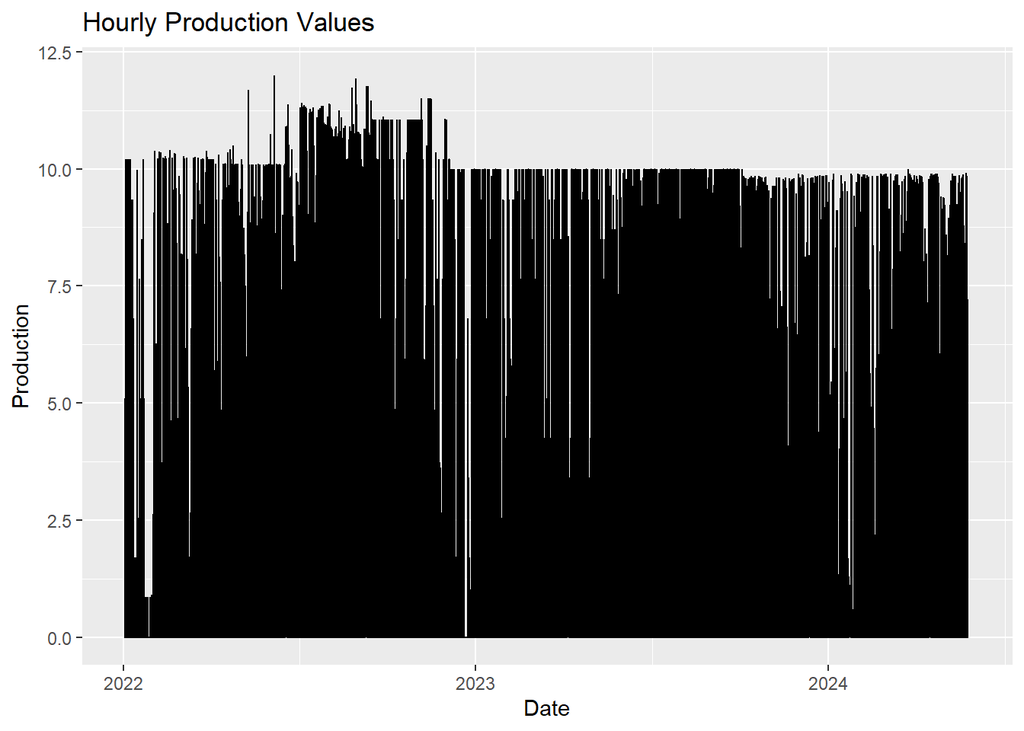

```r
ggplot(data,aes(x=dateTime,y=production)) + geom_line() + ggtitle("Hourly Production Values")+xlab("Date")+ylab("Production")
```

The code block above initializes a ggplot object with `data` as the data source and maps `dateTime` to the x-axis and `production` to the y-axis..

The goalis to create a time series plot that visualizes the hourly production values of the solar power plant. This plot helps in understanding the trends and patterns in production over time, providing valuable insights for further analysis and forecasting.

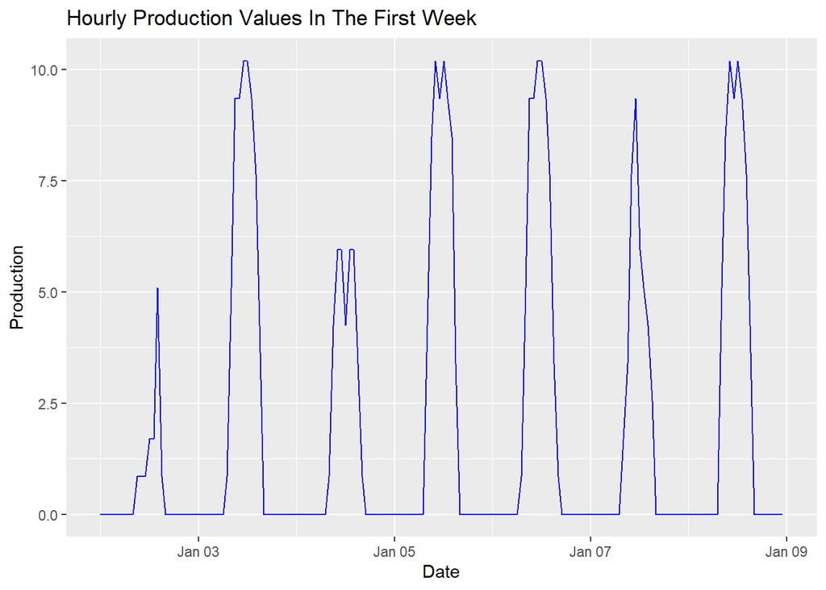

```r
ggplot(data[date >= "2022-01-01" & date <= "2022-01-08"],aes(x=dateTime,y=production)) + geom_line(color="blue") + ggtitle("Hourly Production Values In The First Week")+xlab("Date")+ylab("Production")
```

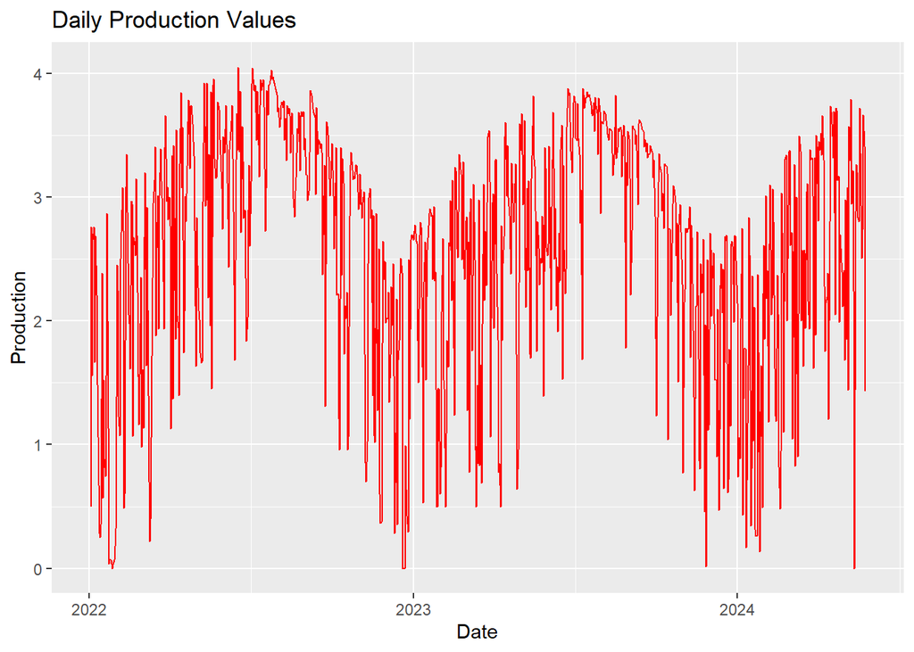

```r
# daily data
daily_series <-  data[,list(daily_production = mean(production)),by= list(date)] #843 rows

daily_series=daily_series[!is.na(daily_production)] #837 rows, NA's are omitted

ggplot(daily_series,aes(x=date,y=daily_production)) + geom_line(color="red") + ggtitle("Daily Production Values")+xlab("Date")+ylab("Production")
```

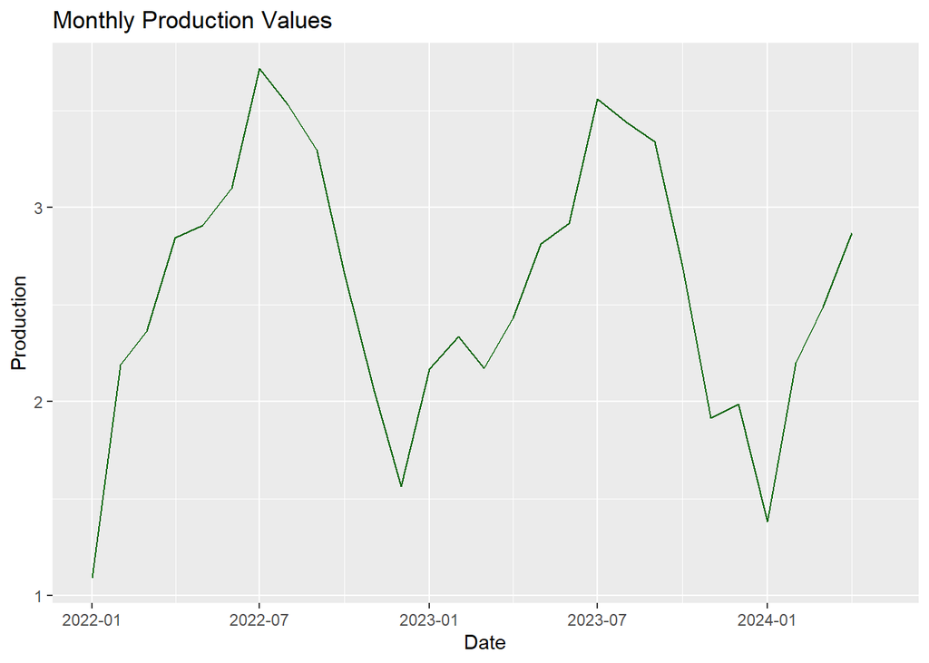

```r
data$month = month(data$date)
data$year = year(data$date)

monthly_production <-  data[,list(monthly_production = mean(production)),by= list(month,year)]
monthly_production[,date := as.Date(paste(year,"-",month,"-01",sep=""), format='%Y-%m-%d')] #2024-4 monthly production is NA, 28 rows


ggplot(monthly_production,aes(x=date,y=monthly_production)) + geom_line(color="darkgreen") + ggtitle("Monthly Production Values")+xlab("Date")+ylab("Production")
```

The goal of this code block is to visualize solar power production data at different time resolutions: hourly for a specific week, daily, and monthly. This helps in understanding production trends and patterns over various time scales, providing valuable insights for further analysis and forecasting.

As evident from the plots, the output values exhibit clear patterns over time, rather than appearing random. These patterns can be observed on an hourly, daily, and monthly basis. Additionally, autocorrelation and the influence of other variables should be considered. Moving forward, the project will delve into these dependencies.

The next steps involve modeling the time series using various predictors and experimenting with different models at each stage to accurately describe solar power production.

# Seasonality and Trend Analysis

To explain the code block below, Adds monthFactor and dayFactor columns to represent the month and day as factors. Adds a trend column to represent a sequential trend variable.

Fits a linear model (Model_trend) using the trend column to predict daily production. Adds a trend_const column with predictions from the linear model.

Plots actual daily production values and trend predictions on the same graph. Plots the residuals (differences between actual values and trend predictions) to assess the model fit.

Uses checkresiduals to visualize and diagnose residuals of the model.

The goal is to analyze the trend in daily production values by fitting a linear model with a trend variable, visualize the trend and its fit, and examine the residuals to evaluate the model’s performance.

```r
daily_series[,monthFactor := as.factor(format(daily_series$date, "%m"))] #Added month as a separate column
daily_series[,dayFactor   := as.factor(format(daily_series$date, "%d"))]
daily_series[,trend := 1: .N] #Added trend as a separate column
print(daily_series)
```

```
##            date daily_production monthFactor dayFactor trend
##          <Date>            <num>      <fctr>    <fctr> <int>
##   1: 2022-01-02        0.4958333          01        02     1
##   2: 2022-01-03        2.7625000          01        03     2
##   3: 2022-01-04        1.5583333          01        04     3
##   4: 2022-01-05        2.6562500          01        05     4
##   5: 2022-01-06        2.7625000          01        06     5
##  ---
## 870: 2024-05-20        2.5066667          05        20   870
## 871: 2024-05-21        2.7366667          05        21   871
## 872: 2024-05-22        3.6691667          05        22   872
## 873: 2024-05-23        3.4154167          05        23   873
## 874: 2024-05-24        1.4320833          05        24   874
```

```r
# model with trend
Model_trend<- lm(daily_production ~ trend, daily_series)
summary(Model_trend)
```

```
##
## Call:
## lm(formula = daily_production ~ trend, data = daily_series)
##
## Residuals:
##     Min      1Q  Median      3Q     Max
## -2.6153 -0.5737  0.2207  0.7812  1.4499
##
## Coefficients:
##               Estimate Std. Error t value Pr(>|t|)
## (Intercept)  2.617e+00  6.678e-02   39.19   <2e-16 ***
## trend       -8.333e-05  1.322e-04   -0.63    0.529
## ---
## Signif. codes:  0 '***' 0.001 '**' 0.01 '*' 0.05 '.' 0.1 ' ' 1
##
## Residual standard error: 0.9863 on 872 degrees of freedom
## Multiple R-squared:  0.0004552,  Adjusted R-squared:  -0.000691
## F-statistic: 0.3971 on 1 and 872 DF,  p-value: 0.5287
```

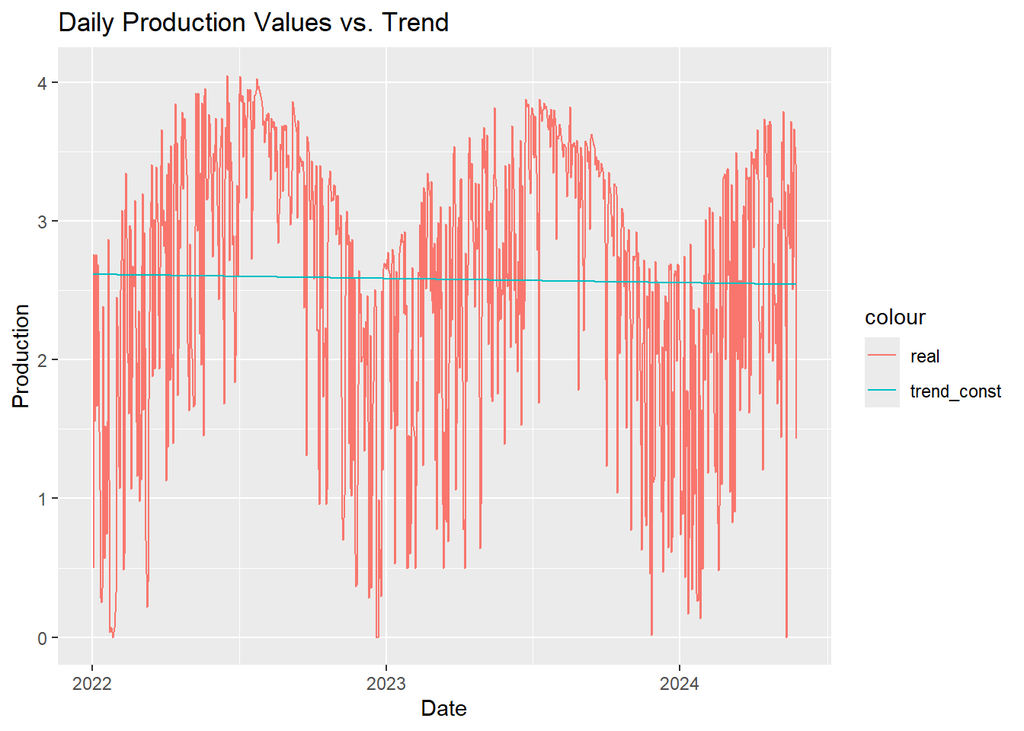

```r
daily_series[,trend_const := predict(Model_trend,daily_series)] #Added prediction as a separate column
ggplot(daily_series,aes(x=date)) + geom_line(aes(y=daily_production, color="real")) + geom_line(aes(y=trend_const, color="trend_const")) + ggtitle("Daily Production Values vs. Trend")+xlab("Date")+ylab("Production")
```

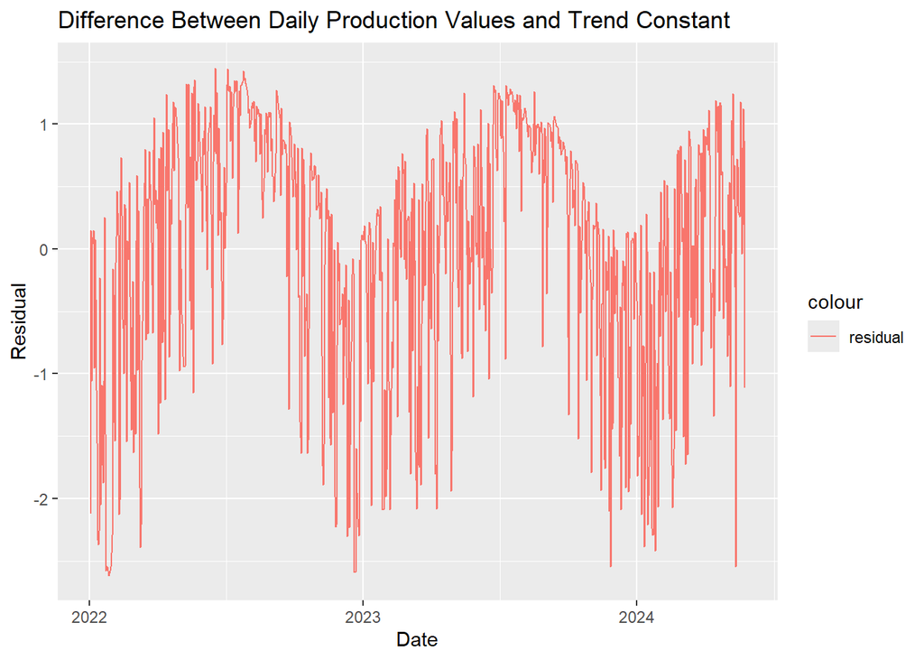

```r
# residuals
ggplot(daily_series,aes(x=date)) + geom_line(aes(y=daily_production - trend_const, color="residual")) + ggtitle("Difference Between Daily Production Values and Trend Constant")+xlab("Date")+ylab("Residual")
```

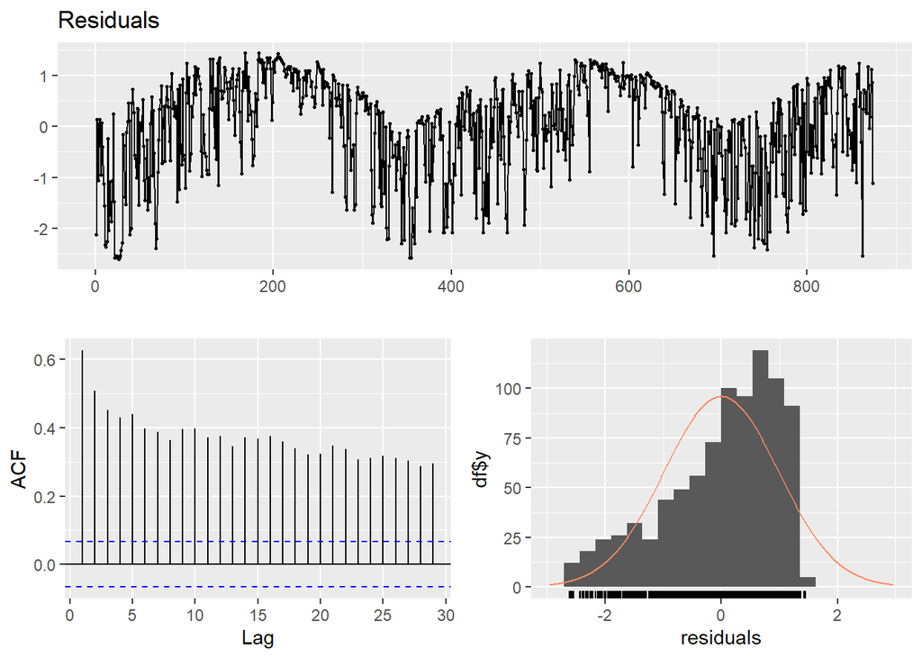

```
##
##  Ljung-Box test
##
## data:  Residuals
## Q* = 1749.6, df = 10, p-value < 2.2e-16
##
## Model df: 0.   Total lags used: 10
```

```r
checkresiduals(Model_trend$residuals)
```

The model constructed with the trend component indicates that daily production values are influenced by more than just a trend. Residual analysis shows that the residuals are not independent and do not have constant variance. They have high autocorrelation. Furthermore, winter production values are significantly below the trend line, while summer values are above it, suggesting that seasonality also affects the production values.

```r
# add seasonality component

Model_trend_seasonality <- lm(daily_production ~monthFactor + trend, daily_series)
summary(Model_trend_seasonality)
```

```
##
## Call:
## lm(formula = daily_production ~ monthFactor + trend, data = daily_series)
##
## Residuals:
##     Min      1Q  Median      3Q     Max
## -2.8511 -0.4417  0.1334  0.5588  1.3754
##
## Coefficients:
##                Estimate Std. Error t value Pr(>|t|)
## (Intercept)   1.530e+00  8.920e-02  17.153  < 2e-16 ***
## monthFactor02 6.883e-01  1.150e-01   5.984 3.19e-09 ***
## monthFactor03 7.853e-01  1.125e-01   6.979 5.93e-12 ***
## monthFactor04 1.159e+00  1.137e-01  10.196  < 2e-16 ***
## monthFactor05 1.273e+00  1.150e-01  11.072  < 2e-16 ***
## monthFactor06 1.461e+00  1.269e-01  11.515  < 2e-16 ***
## monthFactor07 2.088e+00  1.256e-01  16.630  < 2e-16 ***
## monthFactor08 1.934e+00  1.256e-01  15.401  < 2e-16 ***
## monthFactor09 1.765e+00  1.269e-01  13.901  < 2e-16 ***
## monthFactor10 1.124e+00  1.259e-01   8.929  < 2e-16 ***
## monthFactor11 4.331e-01  1.274e-01   3.399 0.000706 ***
## monthFactor12 2.138e-01  1.265e-01   1.690 0.091340 .
## trend         5.576e-05  1.044e-04   0.534 0.593576
## ---
## Signif. codes:  0 '***' 0.001 '**' 0.01 '*' 0.05 '.' 0.1 ' ' 1
##
## Residual standard error: 0.7642 on 861 degrees of freedom
## Multiple R-squared:  0.4075, Adjusted R-squared:  0.3993
## F-statistic: 49.35 on 12 and 861 DF,  p-value: < 2.2e-16
```

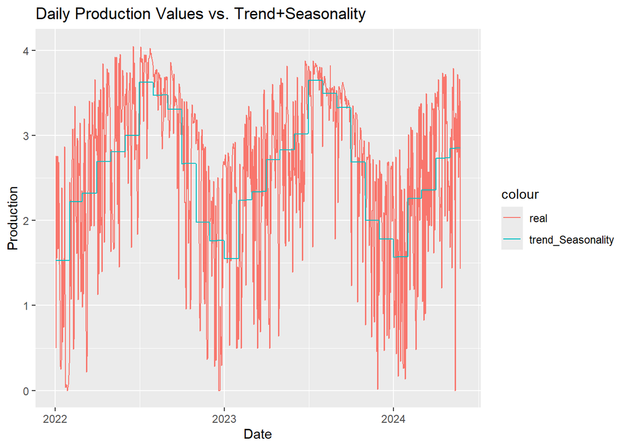

```r
daily_series[,trend_Seasonality := predict(Model_trend_seasonality,daily_series)]
ggplot(daily_series,aes(x=date)) + geom_line(aes(y=daily_production, color="real")) + geom_line(aes(y=trend_Seasonality, color="trend_Seasonality")) + ggtitle("Daily Production Values vs. Trend+Seasonality")+xlab("Date")+ylab("Production")
```

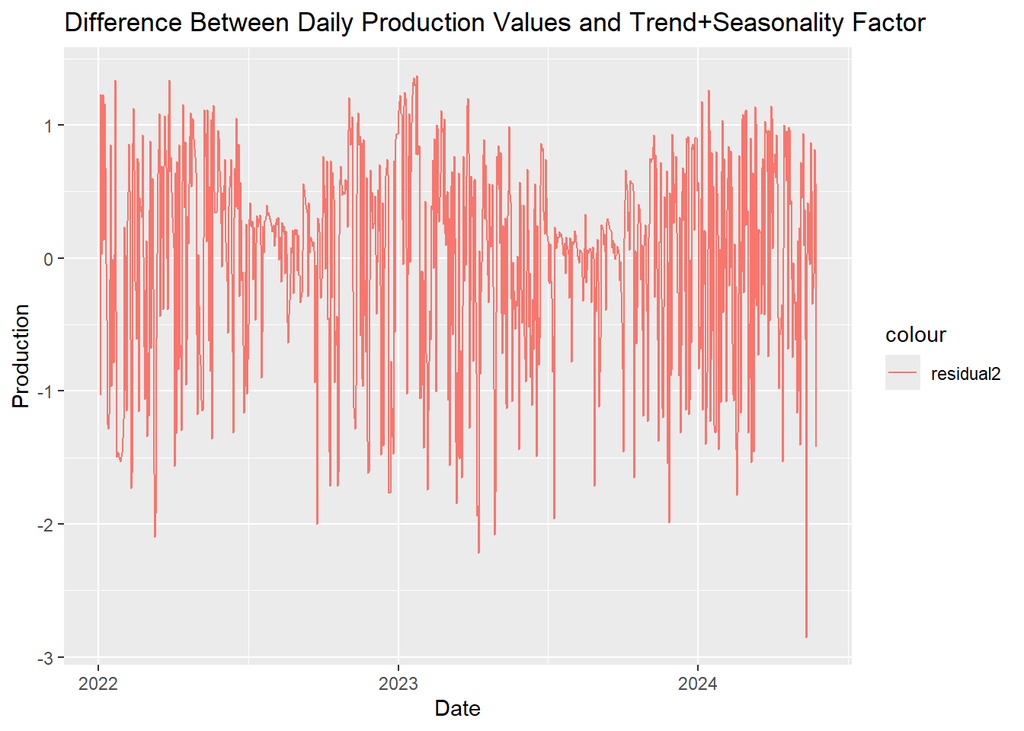

```r
# residuals
ggplot(daily_series,aes(x=date)) + geom_line(aes(y=daily_production - trend_Seasonality, color="residual2")) +  ggtitle("Difference Between Daily Production Values and Trend+Seasonality Factor")+xlab("Date")+ylab("Production")
```

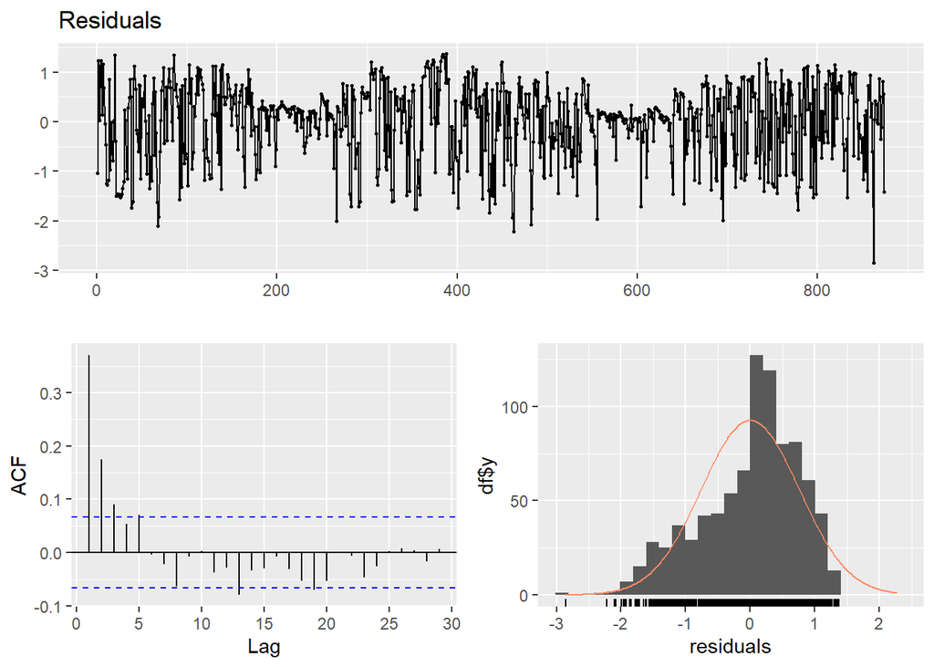

```
##
##  Ljung-Box test
##
## data:  Residuals
## Q* = 165.1, df = 10, p-value < 2.2e-16
##
## Model df: 0.   Total lags used: 10
```

```r
checkresiduals(Model_trend_seasonality$residuals)
```

By adding a seasonality component, the model captures the production values more accurately. While incorporating seasonality improved the model, the residuals still exhibit non-constant variance, high autocorrelation, and a lack of normal distribution. Additionally, other variables, such as weather data, still need to be considered.

# Anaylsis of the time series

The adf.test() function from the tseries package performs the Augmented Dickey-Fuller (ADF) test on the daily_production values. The ADF test is used to determine whether a time series is stationary (i.e., its statistical properties do not change over time).

The goal of the code block below is to test the stationarity of the daily production values. Stationarity is an important property for time series data in forecasting models, as many models assume the underlying time series is stationary. The ADF test helps in verifying this assumption.

```r
adf.test(daily_series$daily_production)
```

```
##
##  Augmented Dickey-Fuller Test
##
## data:  daily_series$daily_production
## Dickey-Fuller = -4.2294, Lag order = 9, p-value = 0.01
## alternative hypothesis: stationary
```

Test results show that, since p-value is not significant enough (< 0.05), null hypothesis can b rejected. Hence time series is concluded to be stationary.

```r
#daily time series
daily_ts <- ts(daily_series$daily_production, start = c(2022,01,01), frequency = 365)
rootTest=ur.kpss(daily_ts)
summary(rootTest)
```

```
##
## #######################
## # KPSS Unit Root Test #
## #######################
##
## Test is of type: mu with 6 lags.
##
## Value of test-statistic is: 0.4666
##
## Critical value for a significance level of:
##                 10pct  5pct 2.5pct  1pct
## critical values 0.347 0.463  0.574 0.739
```

```
 Unit root test helps us to determine whether differencing is needed. It is another measure to examine stationarity. Since test statistic is higher than critical value of 5 percent (0.463 < 0.4666), it can be concluded that differencing is required.
```

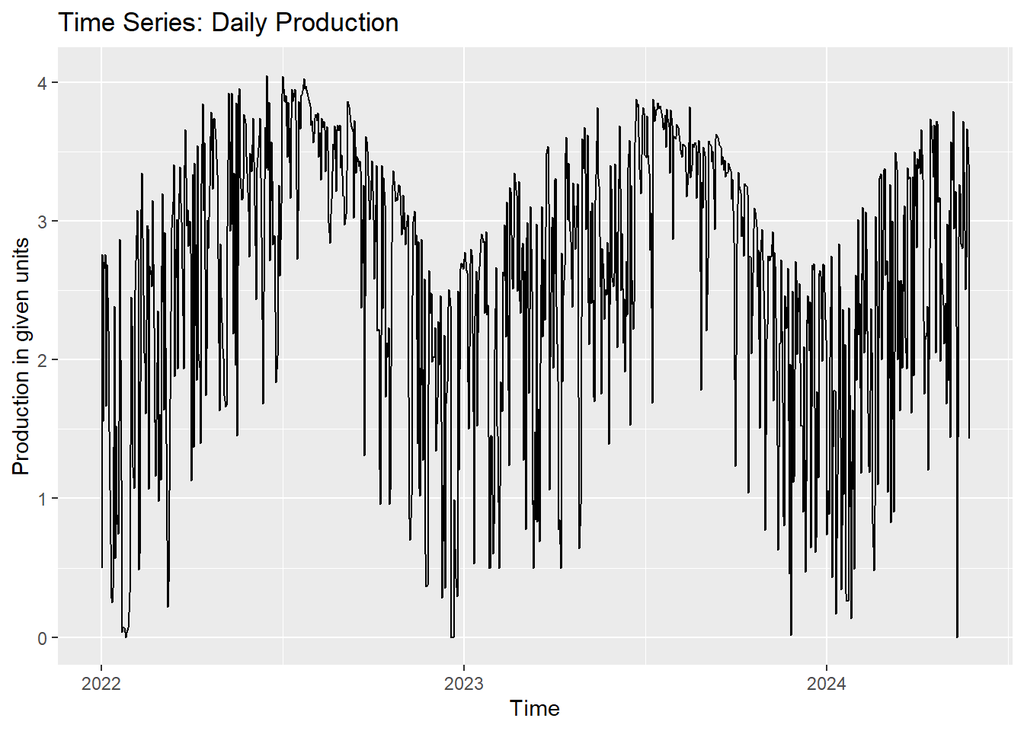

```r
### time plot
autoplot(daily_ts) +
  ggtitle("Time Series: Daily Production") +
  ylab("Production in given units")
```

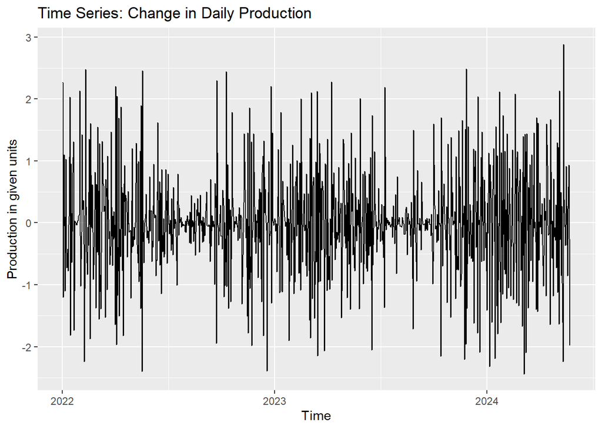

```r
### take the first difference
ddaily_ts <- diff(daily_ts)

### time plot
autoplot(ddaily_ts) +
  ggtitle("Time Series: Change in Daily Production") +
  ylab("Production in given units")
```

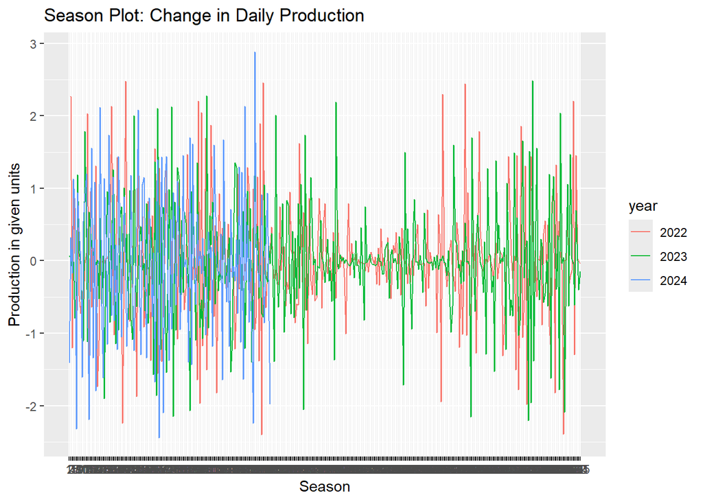

```r
### seasonality investigation
ggseasonplot(ddaily_ts) +
  ggtitle("Season Plot: Change in Daily Production") +
  ylab("Production in given units")
```

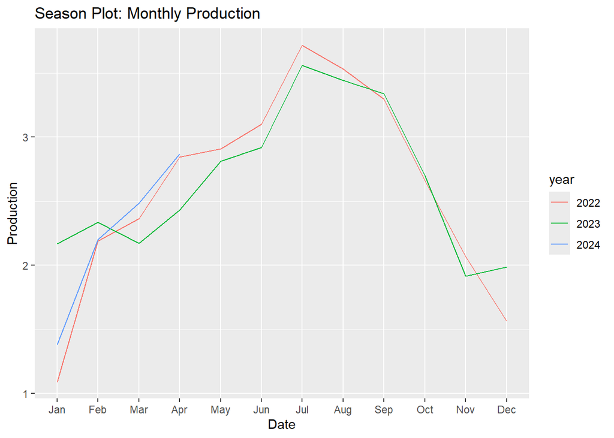

```r
ggseasonplot(ts(monthly_production$monthly_production, start = c(2022,01), frequency = 12)) +  ggtitle("Season Plot: Monthly Production")+xlab("Date")+ylab("Production")
```

```r
print(monthly_production)
```

```
##     month  year monthly_production       date
##     <num> <num>              <num>     <Date>
##  1:     1  2022           1.090819 2022-01-01
##  2:     2  2022           2.189866 2022-02-01
##  3:     3  2022           2.363790 2022-03-01
##  4:     4  2022           2.845375 2022-04-01
##  5:     5  2022           2.907137 2022-05-01
##  6:     6  2022           3.099667 2022-06-01
##  7:     7  2022           3.718468 2022-07-01
##  8:     8  2022           3.532944 2022-08-01
##  9:     9  2022           3.298097 2022-09-01
## 10:    10  2022           2.660820 2022-10-01
## 11:    11  2022           2.067222 2022-11-01
## 12:    12  2022           1.561519 2022-12-01
## 13:     1  2023           2.167500 2023-01-01
```

[output cut: 17 more lines]

Examining the time series plot of daily production values and their changes over the given period reveals that the data’s variability is not constant over time. Notably, the variability is highest at the beginning and end of the year. This needs to be considered when constructing the model, with efforts made to minimize this variability in the linear regression model.

Additionally, comparing the monthly trends at the start of 2022 and 2024 shows a noticeable similarity.

dailyts <- ts(daily_ts, freq=15): Adjusts the frequency of the time series for decomposition. The frequency should be set based on the periodicity of the data (e.g., 365 for daily data over a year). Here, 15 is used as an example.

daily_ts_additive <- decompose(dailyts, type=“additive”): Decomposes the time series into additive components (trend, seasonal, and random). plot(daily_ts_additive): Plots the components of the additive decomposition.

daily_ts_multip <- decompose(dailyts, type=“multiplicative”): Decomposes the time series into multiplicative components (trend, seasonal, and random). plot(daily_ts_multip): Plots the components of the multiplicative decomposition.

The goal of this code block is to analyze the structure of the daily production time series by examining its autocorrelation and partial autocorrelation, and by decomposing the series into trend, seasonal, and random components. Decomposition helps in understanding the underlying patterns in the data, which can be useful for forecasting and identifying seasonality and trends.

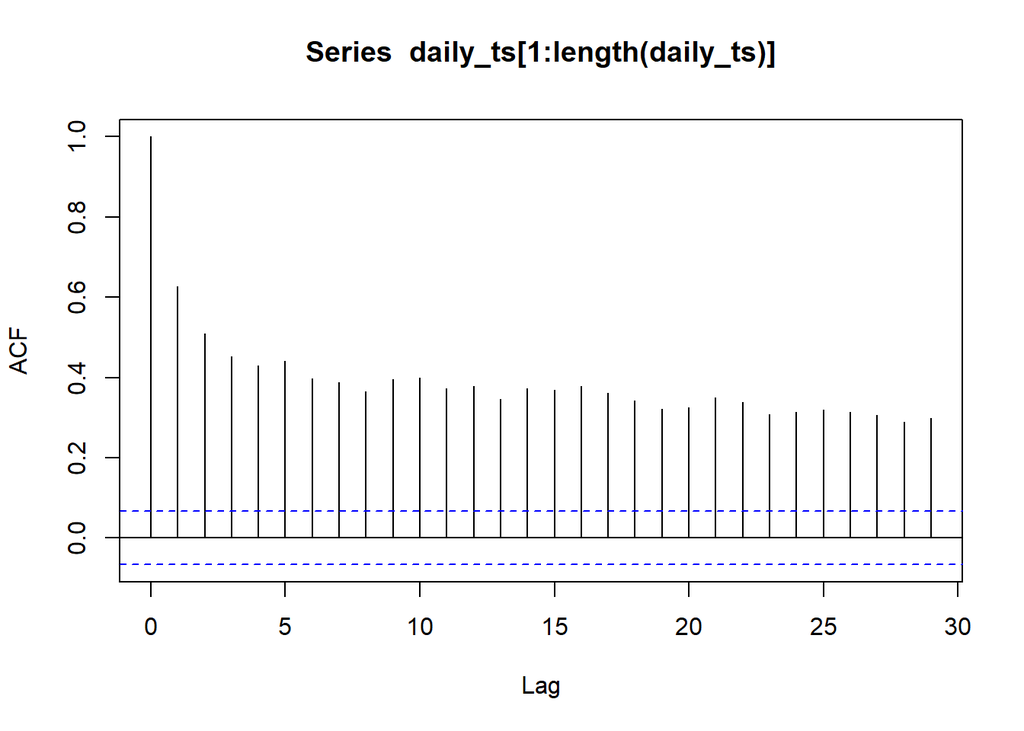

```r
#Time Series Decomposition
acf(daily_ts[1:length(daily_ts)])
```

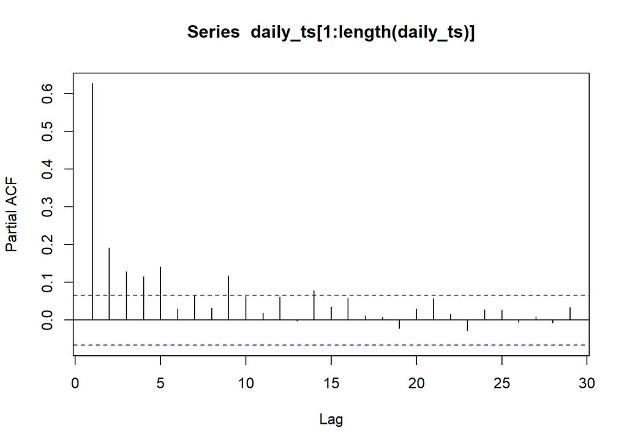

```r
pacf(daily_ts[1:length(daily_ts)])
```

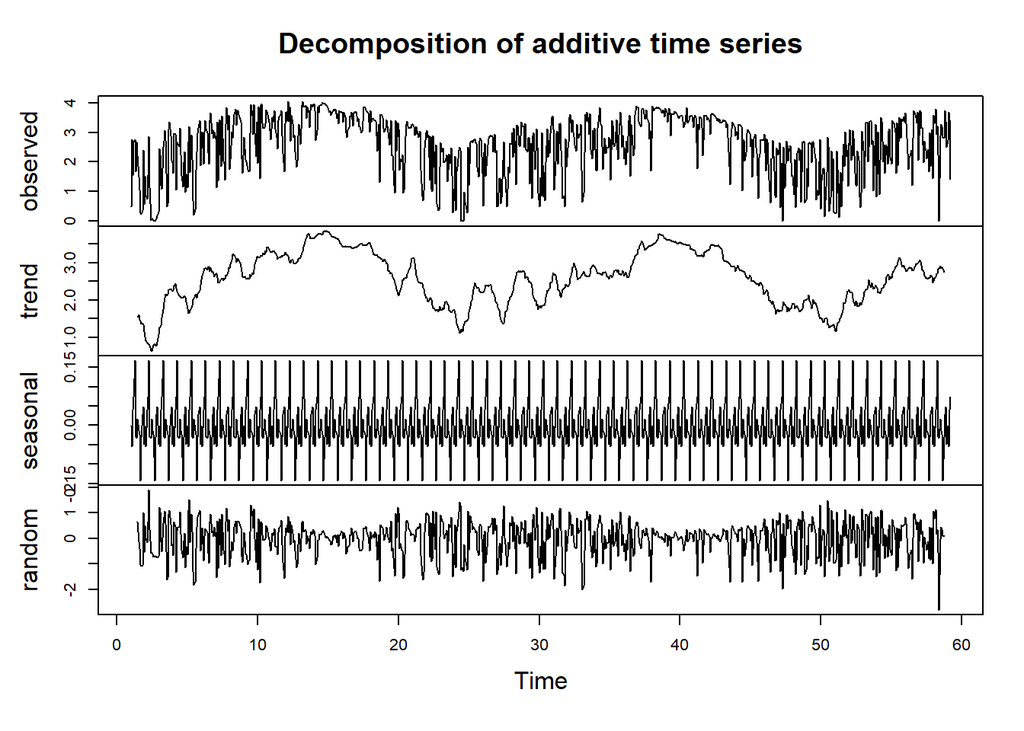

```r
dailyts <- ts(daily_ts, freq=15)

daily_ts_additive<-decompose(dailyts, type="additive")
plot(daily_ts_additive)
```

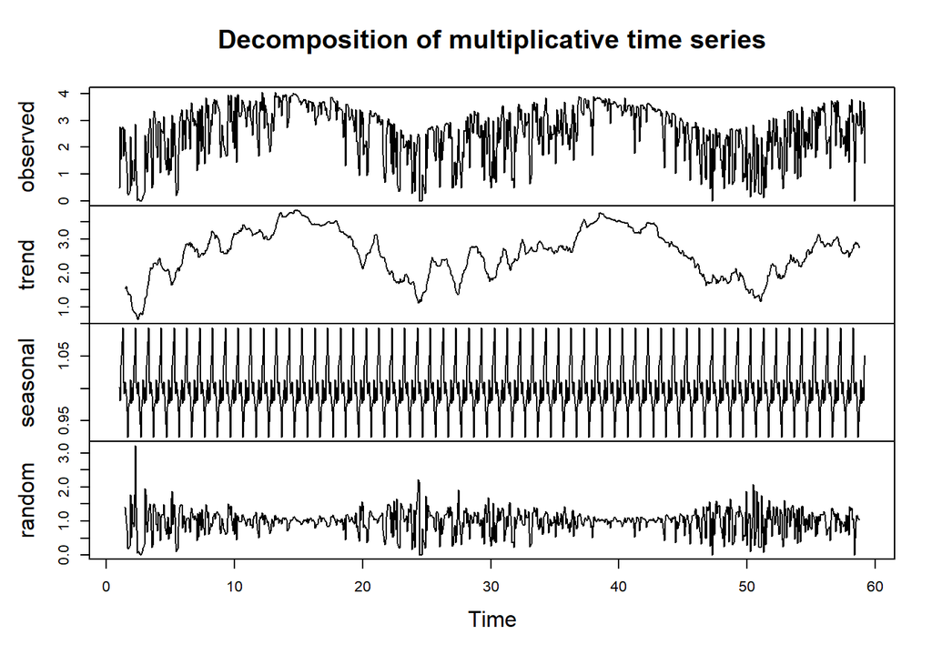

```r
daily_ts_multip<-decompose(dailyts, type="multiplicative")
plot(daily_ts_multip)
```

The time series of daily production values exhibits high autocorrelation. Additionally, both the additive and multiplicative decomposition plots of the series show that the random component violates the assumption of constant variance. Given this, ARIMA or a regression model appears to be the most suitable for the data.

Upon examining the PACF (Partial Autocorrelation Function) graph, which isolates the effects between lags, it is evident that the last five days significantly influence the current day’s value.

```r
setDT(weather_data)

daily_weather <- weather_data[, lapply(.SD, mean, na.rm = TRUE), by = .(date)]


daily_weather=daily_weather[!is.na(production)] #837 rows, NA's are omitted

print(daily_weather)
```

```
##            date  hour dswrf_surface_38_35 dswrf_surface_38.5_35.25
##          <Date> <num>               <num>                    <num>
##   1: 2022-01-02  11.5            24.20667                 36.60583
##   2: 2022-01-03  11.5           129.70833                119.42667
##   3: 2022-01-04  11.5            93.53417                 73.21500
##   4: 2022-01-05  11.5           124.29750                112.45167
##   5: 2022-01-06  11.5           126.86667                117.23500
##  ---
## 870: 2024-05-20  11.5           155.18567                227.45367
## 871: 2024-05-21  11.5           230.87033                225.00700
## 872: 2024-05-22  11.5           365.03000                360.24517
## 873: 2024-05-23  11.5           360.30717                296.07167
## 874: 2024-05-24  11.5           179.43600                188.89633
##      dswrf_surface_37.75_34.75 dswrf_surface_38.75_34.5
##                          <num>                    <num>
```

[output cut: 1389 more lines]

```r
daily_weather[,residual_model2 := c(daily_series$daily_production - daily_series$trend_Seasonality)]
```

```r
print(data_avg$TMP_Surface_Avg)
```

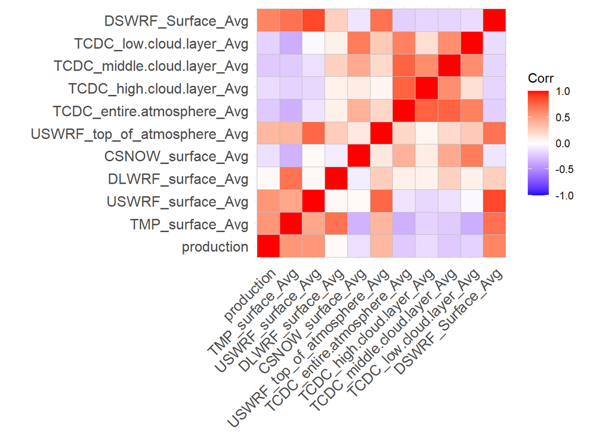

```r
cR <- data_avg[,c(14,13,12,11,10,9,8,7,6,5,4)]

CorrGraph <- as.data.frame(cR)
corr <- cor(CorrGraph, use = "pairwise.complete.obs")

ggcorrplot(corr)
```

As seen in the above figure,DSWRF_Surface_Avg and USWRF_Surface_Avg and TMP_Surface_Avg have a stronger correlation with production values more than other variables. So we expect to use these variables in our model, however it will be better to analyze while building the model.

```r
avgdata_lagged = data_avg
avgdata_lagged$month <- month(avgdata_lagged$date)

# Create lagged variables for days 3 and 5
avgdata_lagged <- avgdata_lagged %>%
  arrange(date) %>%
  mutate(lag_3 = lag(production, 3),
         lag_5 = lag(production, 5))

# Filter the data for hours between 7 and 18
```

# Moving averages

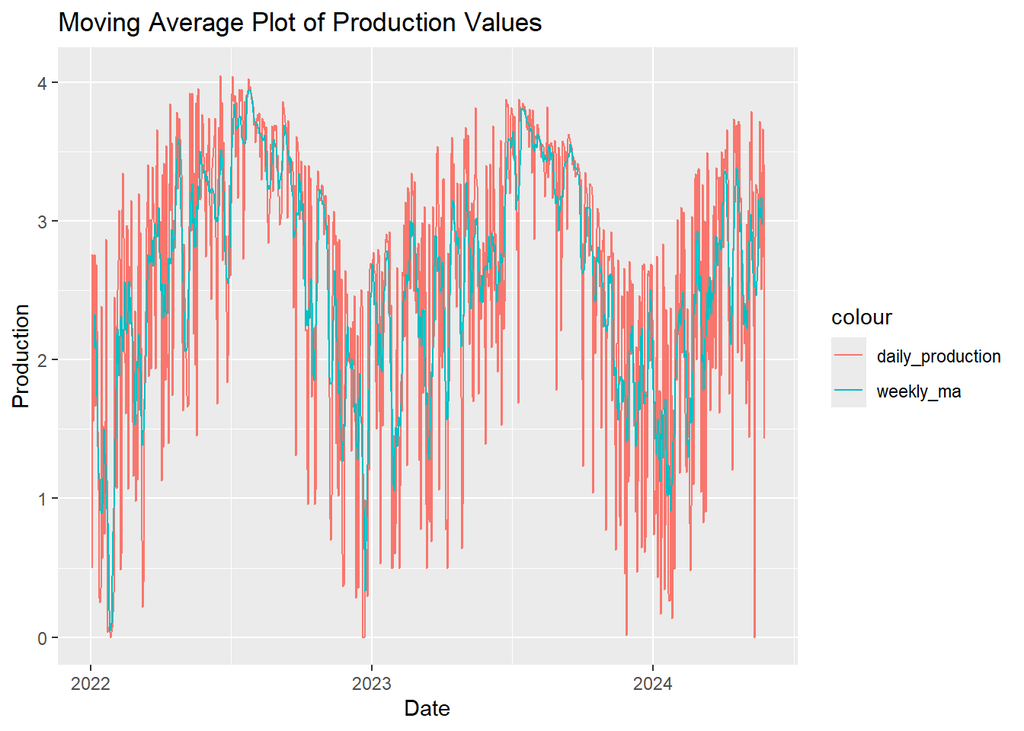

```r
daily_series[,ma_week := ma(daily_series$daily_production, order=7)]
ggplot(daily_series,aes(x=date)) +geom_line(aes(y = daily_production, color = "daily_production")) + geom_line(aes(y = ma_week, color = "weekly_ma"))  +  ggtitle("Moving Average Plot of Production Values")+xlab("Date")+ylab("Production")
```

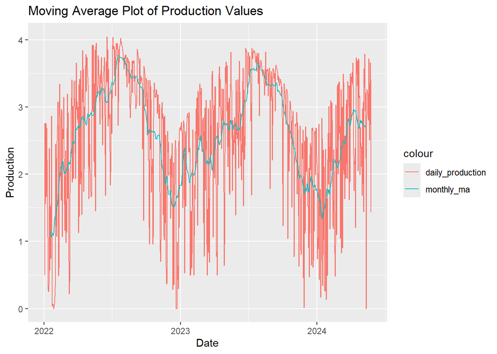

```r
daily_series[,ma_month := ma(daily_series$daily_production, order=30)]
ggplot(daily_series,aes(x=date)) +geom_line(aes(y = daily_production, color = "daily_production")) + geom_line(aes(y = ma_month, color = "monthly_ma"))  +  ggtitle("Moving Average Plot of Production Values")+xlab("Date")+ylab("Production")
```

The provided code calculates and visualizes the weekly and monthly moving averages of daily production values in the daily_series data frame. The moving averages are computed using 7-day and 30-day windows, respectively, to smooth out short-term fluctuations and highlight longer-term trends. These moving averages are then plotted alongside the raw daily production values, allowing for a clearer visualization of the underlying patterns. This process is crucial for identifying trends, seasonal effects, and other significant patterns in the data, which can inform better decision-making and strategy formulation. By reducing noise and focusing on overall trends, the moving averages provide valuable insights into the production values over time, facilitating more informed operational and strategic decisions.

# Regression Models

Now it’s time to build regression models. We are going to build various regression models and compare them

```r
print(daily_series)
```

```
##            date daily_production monthFactor dayFactor trend trend_const
##          <Date>            <num>      <fctr>    <fctr> <int>       <num>
##   1: 2022-01-02        0.4958333          01        02     1    2.617377
##   2: 2022-01-03        2.7625000          01        03     2    2.617293
##   3: 2022-01-04        1.5583333          01        04     3    2.617210
##   4: 2022-01-05        2.6562500          01        05     4    2.617127
##   5: 2022-01-06        2.7625000          01        06     5    2.617043
##  ---
## 870: 2024-05-20        2.5066667          05        20   870    2.544961
## 871: 2024-05-21        2.7366667          05        21   871    2.544878
## 872: 2024-05-22        3.6691667          05        22   872    2.544794
## 873: 2024-05-23        3.4154167          05        23   873    2.544711
## 874: 2024-05-24        1.4320833          05        24   874    2.544628
##      trend_Seasonality  ma_week ma_month
##                  <num>     <ts>     <ts>
##   1:          1.530151       NA       NA
##   2:          1.530206       NA       NA
##   3:          1.530262       NA       NA
##   4:          1.530318 2.084524       NA
##   5:          1.530374 2.329702       NA
##  ---
## 870:          2.851531 3.173512       NA
## 871:          2.851587 2.977321       NA
## 872:          2.851642       NA       NA
## 873:          2.851698       NA       NA
## 874:          2.851754       NA       NA
```

```r
fit1=lm(production~as.factor(hour)+as.factor(month)+DSWRF_Surface_Avg+USWRF_surface_Avg +CSNOW_surface_Avg
+TMP_surface_Avg+lag_5,avgdata_lagged)
summary(fit1)
```

```
##
## Call:
## lm(formula = production ~ as.factor(hour) + as.factor(month) +
##     DSWRF_Surface_Avg + USWRF_surface_Avg + CSNOW_surface_Avg +
##     TMP_surface_Avg + lag_5, data = avgdata_lagged)
##
## Residuals:
##     Min      1Q  Median      3Q     Max
## -9.1278 -0.4954 -0.0185  0.7486  7.6570
##
## Coefficients:
##                      Estimate Std. Error t value Pr(>|t|)
## (Intercept)        -1.709e+01  7.750e-01 -22.050  < 2e-16 ***
## as.factor(hour)1    3.066e-02  7.526e-02   0.407   0.6838
## as.factor(hour)2    5.976e-02  7.528e-02   0.794   0.4273
## as.factor(hour)3    8.658e-02  7.532e-02   1.150   0.2503
## as.factor(hour)4    9.460e-02  7.537e-02   1.255   0.2094
## as.factor(hour)5    1.920e-01  7.540e-02   2.546   0.0109 *
## as.factor(hour)6    7.784e-01  7.540e-02  10.324  < 2e-16 ***
## as.factor(hour)7    2.827e+00  7.525e-02  37.567  < 2e-16 ***
## as.factor(hour)8    5.151e+00  7.569e-02  68.055  < 2e-16 ***
## as.factor(hour)9    6.531e+00  7.773e-02  84.021  < 2e-16 ***
## as.factor(hour)10   4.837e+00  9.229e-02  52.405  < 2e-16 ***
## as.factor(hour)11   4.386e+00  9.678e-02  45.318  < 2e-16 ***
## as.factor(hour)12   3.978e+00  9.870e-02  40.302  < 2e-16 ***
## as.factor(hour)13   3.474e+00  1.012e-01  34.341  < 2e-16 ***
## as.factor(hour)14   2.460e+00  1.036e-01  23.733  < 2e-16 ***
## as.factor(hour)15   7.953e-01  1.036e-01   7.679 1.68e-14 ***
## as.factor(hour)16  -4.581e-01  9.729e-02  -4.708 2.52e-06 ***
## as.factor(hour)17  -1.421e+00  9.396e-02 -15.121  < 2e-16 ***
## as.factor(hour)18  -1.619e+00  9.062e-02 -17.867  < 2e-16 ***
## as.factor(hour)19  -1.247e+00  8.645e-02 -14.422  < 2e-16 ***
## as.factor(hour)20  -9.765e-01  8.150e-02 -11.982  < 2e-16 ***
## as.factor(hour)21  -8.559e-01  7.790e-02 -10.987  < 2e-16 ***
## as.factor(hour)22  -2.410e-02  7.551e-02  -0.319   0.7496
## as.factor(hour)23  -2.774e-02  7.524e-02  -0.369   0.7124
## as.factor(month)2   2.622e-01  4.964e-02   5.282 1.29e-07 ***
## as.factor(month)3   4.869e-02  4.989e-02   0.976   0.3292
## as.factor(month)4  -5.739e-01  5.761e-02  -9.961  < 2e-16 ***
## as.factor(month)5  -6.778e-01  6.031e-02 -11.239  < 2e-16 ***
## as.factor(month)6  -9.001e-01  7.148e-02 -12.592  < 2e-16 ***
## as.factor(month)7  -7.151e-01  7.756e-02  -9.220  < 2e-16 ***
## as.factor(month)8  -9.311e-01  8.527e-02 -10.919  < 2e-16 ***
## as.factor(month)9  -4.776e-01  7.489e-02  -6.377 1.84e-10 ***
## as.factor(month)10 -3.299e-01  6.467e-02  -5.101 3.40e-07 ***
## as.factor(month)11 -2.717e-01  5.784e-02  -4.696 2.66e-06 ***
## as.factor(month)12 -8.790e-02  5.422e-02  -1.621   0.1050
## DSWRF_Surface_Avg   4.046e-03  1.638e-04  24.697  < 2e-16 ***
## USWRF_surface_Avg   5.771e-03  4.494e-04  12.840  < 2e-16 ***
## CSNOW_surface_Avg  -1.530e+00  7.115e-02 -21.508  < 2e-16 ***
## TMP_surface_Avg     6.280e-02  2.859e-03  21.969  < 2e-16 ***
## lag_5              -4.530e-02  7.103e-03  -6.377 1.84e-10 ***
## ---
## Signif. codes:  0 '***' 0.001 '**' 0.01 '*' 0.05 '.' 0.1 ' ' 1
##
## Residual standard error: 1.572 on 20929 degrees of freedom
##   (55 observations deleted due to missingness)
## Multiple R-squared:  0.8192, Adjusted R-squared:  0.8188
## F-statistic:  2431 on 39 and 20929 DF,  p-value: < 2.2e-16
```

```r
AIC(fit1)
```

```
## [1] 78524.96
```

```r
fit2=lm(sqrt(production)~as.factor(hour)+as.factor(month)+DSWRF_Surface_Avg+TMP_surface_Avg+TCDC_middle.cloud.layer_Avg+ CSNOW_surface_Avg
+lag_5,avgdata_lagged)
summary(fit2)
```

```
##
## Call:
## lm(formula = sqrt(production) ~ as.factor(hour) + as.factor(month) +
##     DSWRF_Surface_Avg + TMP_surface_Avg + TCDC_middle.cloud.layer_Avg +
##     CSNOW_surface_Avg + lag_5, data = avgdata_lagged)
##
## Residuals:
##      Min       1Q   Median       3Q      Max
## -3.10548 -0.15852 -0.00557  0.22919  2.06465
##
## Coefficients:
##                               Estimate Std. Error t value Pr(>|t|)
## (Intercept)                 -4.460e+00  2.065e-01 -21.597  < 2e-16 ***
## as.factor(hour)1             7.054e-03  2.206e-02   0.320 0.749096
## as.factor(hour)2             1.375e-02  2.206e-02   0.623 0.533196
## as.factor(hour)3             1.914e-02  2.208e-02   0.867 0.386014
## as.factor(hour)4             3.793e-02  2.208e-02   1.718 0.085884 .
## as.factor(hour)5             1.440e-01  2.209e-02   6.521 7.15e-11 ***
## as.factor(hour)6             5.089e-01  2.209e-02  23.041  < 2e-16 ***
## as.factor(hour)7             1.406e+00  2.205e-02  63.753  < 2e-16 ***
## as.factor(hour)8             2.112e+00  2.215e-02  95.335  < 2e-16 ***
## as.factor(hour)9             2.418e+00  2.261e-02 106.931  < 2e-16 ***
## as.factor(hour)10            2.068e+00  2.680e-02  77.161  < 2e-16 ***
## as.factor(hour)11            1.969e+00  2.799e-02  70.341  < 2e-16 ***
## as.factor(hour)12            1.897e+00  2.848e-02  66.618  < 2e-16 ***
## as.factor(hour)13            1.796e+00  2.921e-02  61.507  < 2e-16 ***
## as.factor(hour)14            1.596e+00  3.004e-02  53.127  < 2e-16 ***
## as.factor(hour)15            1.208e+00  3.020e-02  39.985  < 2e-16 ***
## as.factor(hour)16            7.204e-01  2.835e-02  25.413  < 2e-16 ***
## as.factor(hour)17            1.651e-01  2.752e-02   5.998 2.03e-09 ***
## as.factor(hour)18           -2.170e-01  2.668e-02  -8.134 4.38e-16 ***
## as.factor(hour)19           -2.173e-01  2.552e-02  -8.515  < 2e-16 ***
## as.factor(hour)20           -1.668e-01  2.405e-02  -6.934 4.21e-12 ***
## as.factor(hour)21           -1.502e-01  2.294e-02  -6.544 6.11e-11 ***
## as.factor(hour)22           -3.432e-03  2.213e-02  -0.155 0.876728
## as.factor(hour)23           -6.162e-03  2.205e-02  -0.279 0.779904
## as.factor(month)2            1.611e-01  1.429e-02  11.276  < 2e-16 ***
## as.factor(month)3            1.461e-01  1.437e-02  10.168  < 2e-16 ***
## as.factor(month)4           -4.970e-03  1.661e-02  -0.299 0.764770
## as.factor(month)5           -2.597e-02  1.739e-02  -1.494 0.135202
## as.factor(month)6           -7.261e-02  2.045e-02  -3.551 0.000384 ***
## as.factor(month)7           -5.987e-02  2.216e-02  -2.702 0.006896 **
## as.factor(month)8           -1.433e-01  2.403e-02  -5.963 2.52e-09 ***
## as.factor(month)9           -6.414e-02  2.137e-02  -3.001 0.002692 **
## as.factor(month)10          -4.081e-02  1.868e-02  -2.185 0.028908 *
## as.factor(month)11          -5.901e-02  1.695e-02  -3.482 0.000498 ***
## as.factor(month)12          -5.785e-02  1.596e-02  -3.625 0.000289 ***
## DSWRF_Surface_Avg            1.042e-03  3.852e-05  27.036  < 2e-16 ***
## TMP_surface_Avg              1.626e-02  7.632e-04  21.307  < 2e-16 ***
## TCDC_middle.cloud.layer_Avg -2.298e-03  1.247e-04 -18.428  < 2e-16 ***
## CSNOW_surface_Avg           -3.018e-01  2.263e-02 -13.336  < 2e-16 ***
## lag_5                       -1.225e-02  2.086e-03  -5.873 4.35e-09 ***
## ---
## Signif. codes:  0 '***' 0.001 '**' 0.01 '*' 0.05 '.' 0.1 ' ' 1
##
## Residual standard error: 0.4608 on 20929 degrees of freedom
##   (55 observations deleted due to missingness)
## Multiple R-squared:  0.8657, Adjusted R-squared:  0.8655
## F-statistic:  3460 on 39 and 20929 DF,  p-value: < 2.2e-16
```

```r
AIC(fit2)
```

```
## [1] 27054.08
```

```r
fit3=lm(sqrt(production)~as.factor(hour)+as.factor(month)+DSWRF_Surface_Avg+TMP_surface_Avg+TCDC_middle.cloud.layer_Avg+ CSNOW_surface_Avg
+lag_3,avgdata_lagged)
summary(fit3)
```

```
##
## Call:
## lm(formula = sqrt(production) ~ as.factor(hour) + as.factor(month) +
##     DSWRF_Surface_Avg + TMP_surface_Avg + TCDC_middle.cloud.layer_Avg +
##     CSNOW_surface_Avg + lag_3, data = avgdata_lagged)
##
## Residuals:
##     Min      1Q  Median      3Q     Max
## -3.2163 -0.1517 -0.0005  0.2246  2.0149
##
## Coefficients:
##                               Estimate Std. Error t value Pr(>|t|)
## (Intercept)                 -3.8785949  0.2048988 -18.929  < 2e-16 ***
## as.factor(hour)1             0.0060370  0.0217580   0.277 0.781430
## as.factor(hour)2             0.0117650  0.0217633   0.541 0.588797
## as.factor(hour)3             0.0167269  0.0217707   0.768 0.442304
## as.factor(hour)4             0.0358019  0.0217763   1.644 0.100175
## as.factor(hour)5             0.1407386  0.0217881   6.459 1.07e-10 ***
## as.factor(hour)6             0.5058453  0.0217879  23.217  < 2e-16 ***
## as.factor(hour)7             1.4108496  0.0217555  64.850  < 2e-16 ***
## as.factor(hour)8             2.1325175  0.0218599  97.554  < 2e-16 ***
## as.factor(hour)9             2.4369352  0.0222842 109.357  < 2e-16 ***
## as.factor(hour)10            2.1687456  0.0258308  83.960  < 2e-16 ***
## as.factor(hour)11            1.9588149  0.0270186  72.499  < 2e-16 ***
## as.factor(hour)12            1.7888713  0.0284235  62.936  < 2e-16 ***
## as.factor(hour)13            1.6449280  0.0291880  56.356  < 2e-16 ***
## as.factor(hour)14            1.4241037  0.0294250  48.398  < 2e-16 ***
## as.factor(hour)15            1.0289649  0.0292886  35.132  < 2e-16 ***
## as.factor(hour)16            0.4760813  0.0271699  17.522  < 2e-16 ***
## as.factor(hour)17           -0.0656389  0.0257864  -2.545 0.010920 *
## as.factor(hour)18           -0.3881455  0.0242658 -15.996  < 2e-16 ***
## as.factor(hour)19           -0.2929841  0.0232095 -12.623  < 2e-16 ***
## as.factor(hour)20           -0.1628495  0.0228256  -7.135 1.00e-12 ***
## as.factor(hour)21           -0.0954027  0.0226541  -4.211 2.55e-05 ***
## as.factor(hour)22           -0.0118285  0.0217596  -0.544 0.586724
## as.factor(hour)23           -0.0060134  0.0217522  -0.276 0.782204
## as.factor(month)2            0.1472440  0.0140915  10.449  < 2e-16 ***
## as.factor(month)3            0.1481623  0.0141677  10.458  < 2e-16 ***
## as.factor(month)4            0.0390041  0.0164659   2.369 0.017856 *
## as.factor(month)5            0.0260706  0.0172559   1.511 0.130850
## as.factor(month)6           -0.0087474  0.0203087  -0.431 0.666674
## as.factor(month)7           -0.0003360  0.0219824  -0.015 0.987804
## as.factor(month)8           -0.0849244  0.0238175  -3.566 0.000364 ***
## as.factor(month)9           -0.0353678  0.0211130  -1.675 0.093917 .
## as.factor(month)10          -0.0284646  0.0184246  -1.545 0.122381
## as.factor(month)11          -0.0515303  0.0167156  -3.083 0.002054 **
## as.factor(month)12          -0.0583211  0.0157394  -3.705 0.000212 ***
## DSWRF_Surface_Avg            0.0005141  0.0000397  12.951  < 2e-16 ***
## TMP_surface_Avg              0.0140492  0.0007576  18.544  < 2e-16 ***
## TCDC_middle.cloud.layer_Avg -0.0019384  0.0001231 -15.748  < 2e-16 ***
## CSNOW_surface_Avg           -0.2426113  0.0222573 -10.900  < 2e-16 ***
## lag_3                        0.0554167  0.0022386  24.755  < 2e-16 ***
## ---
## Signif. codes:  0 '***' 0.001 '**' 0.01 '*' 0.05 '.' 0.1 ' ' 1
##
## Residual standard error: 0.4545 on 20931 degrees of freedom
##   (53 observations deleted due to missingness)
## Multiple R-squared:  0.8693, Adjusted R-squared:  0.8691
## F-statistic:  3571 on 39 and 20931 DF,  p-value: < 2.2e-16
```

```r
AIC(fit3)
```

```
## [1] 26485.17
```

```r
fit4=lm(sqrt(production)~as.factor(hour)+as.factor(month)+DSWRF_Surface_Avg+TMP_surface_Avg+TCDC_middle.cloud.layer_Avg+ CSNOW_surface_Avg
+sqrt(lag_5),avgdata_lagged)
summary(fit4)
```

```
##
## Call:
## lm(formula = sqrt(production) ~ as.factor(hour) + as.factor(month) +
##     DSWRF_Surface_Avg + TMP_surface_Avg + TCDC_middle.cloud.layer_Avg +
##     CSNOW_surface_Avg + sqrt(lag_5), data = avgdata_lagged)
##
## Residuals:
##      Min       1Q   Median       3Q      Max
## -3.07521 -0.15874 -0.00457  0.22827  2.06770
##
## Coefficients:
##                               Estimate Std. Error t value Pr(>|t|)
## (Intercept)                 -4.4955768  0.2065230 -21.768  < 2e-16 ***
## as.factor(hour)1             0.0070943  0.0220471   0.322 0.747622
## as.factor(hour)2             0.0138453  0.0220524   0.628 0.530117
## as.factor(hour)3             0.0192799  0.0220663   0.874 0.382278
## as.factor(hour)4             0.0380748  0.0220721   1.725 0.084539 .
## as.factor(hour)5             0.1442213  0.0220773   6.533 6.61e-11 ***
## as.factor(hour)6             0.5091033  0.0220771  23.060  < 2e-16 ***
## as.factor(hour)7             1.4060203  0.0220443  63.782  < 2e-16 ***
## as.factor(hour)8             2.1117248  0.0221443  95.362  < 2e-16 ***
## as.factor(hour)9             2.4180699  0.0225949 107.018  < 2e-16 ***
## as.factor(hour)10            2.0708626  0.0264619  78.258  < 2e-16 ***
## as.factor(hour)11            1.9829279  0.0274809  72.157  < 2e-16 ***
## as.factor(hour)12            1.9310598  0.0285197  67.710  < 2e-16 ***
## as.factor(hour)13            1.8375739  0.0301347  60.979  < 2e-16 ***
## as.factor(hour)14            1.6355311  0.0312320  52.367  < 2e-16 ***
## as.factor(hour)15            1.2460788  0.0314111  39.670  < 2e-16 ***
## as.factor(hour)16            0.7594726  0.0297738  25.508  < 2e-16 ***
## as.factor(hour)17            0.2054139  0.0291019   7.058 1.74e-12 ***
## as.factor(hour)18           -0.1756355  0.0283931  -6.186 6.29e-10 ***
## as.factor(hour)19           -0.1735983  0.0274100  -6.333 2.45e-10 ***
## as.factor(hour)20           -0.1223745  0.0258502  -4.734 2.22e-06 ***
## as.factor(hour)21           -0.1146479  0.0238633  -4.804 1.56e-06 ***
## as.factor(hour)22            0.0165235  0.0224416   0.736 0.461563
## as.factor(hour)23           -0.0024073  0.0220503  -0.109 0.913065
## as.factor(month)2            0.1644327  0.0143031  11.496  < 2e-16 ***
## as.factor(month)3            0.1504213  0.0143900  10.453  < 2e-16 ***
## as.factor(month)4           -0.0003505  0.0166036  -0.021 0.983156
## as.factor(month)5           -0.0210822  0.0173744  -1.213 0.224988
## as.factor(month)6           -0.0672399  0.0204337  -3.291 0.001001 **
## as.factor(month)7           -0.0550759  0.0221546  -2.486 0.012927 *
## as.factor(month)8           -0.1403340  0.0240224  -5.842 5.24e-09 ***
## as.factor(month)9           -0.0619550  0.0213695  -2.899 0.003745 **
## as.factor(month)10          -0.0388915  0.0186739  -2.083 0.037294 *
## as.factor(month)11          -0.0580437  0.0169393  -3.427 0.000612 ***
## as.factor(month)12          -0.0584690  0.0159509  -3.666 0.000247 ***
## DSWRF_Surface_Avg            0.0010432  0.0000377  27.668  < 2e-16 ***
## TMP_surface_Avg              0.0163812  0.0007633  21.461  < 2e-16 ***
## TCDC_middle.cloud.layer_Avg -0.0022976  0.0001245 -18.459  < 2e-16 ***
## CSNOW_surface_Avg           -0.3053875  0.0226239 -13.498  < 2e-16 ***
## sqrt(lag_5)                 -0.0508261  0.0070366  -7.223 5.26e-13 ***
## ---
## Signif. codes:  0 '***' 0.001 '**' 0.01 '*' 0.05 '.' 0.1 ' ' 1
##
## Residual standard error: 0.4606 on 20929 degrees of freedom
##   (55 observations deleted due to missingness)
## Multiple R-squared:  0.8659, Adjusted R-squared:  0.8656
## F-statistic:  3464 on 39 and 20929 DF,  p-value: < 2.2e-16
```

```r
AIC(fit4)
```

```
## [1] 27036.4
```

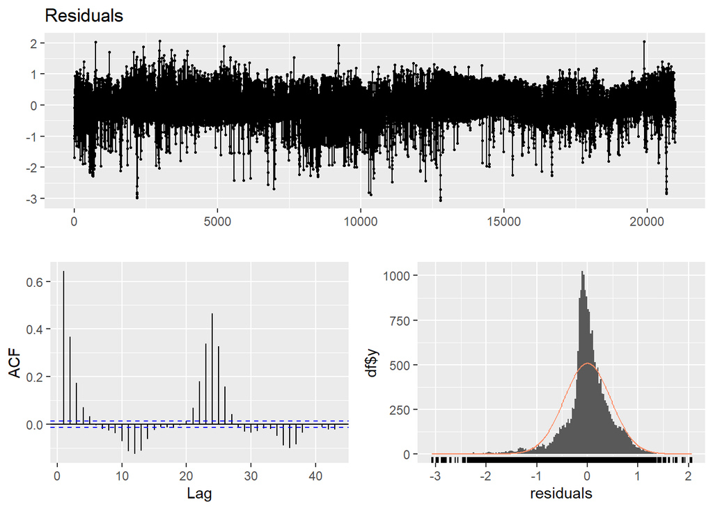

```
##
##  Breusch-Godfrey test for serial correlation of order up to 43
##
## data:  Residuals
## LM test = 10904, df = 43, p-value < 2.2e-16
```

```r
checkresiduals(fit4)
```

```r
avgdata_lagged[,lm4_pred:=(predict(fit4,avgdata_lagged))^2]
```

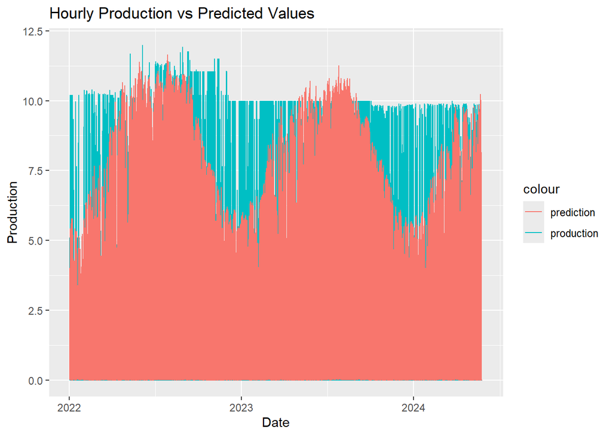

```r
daily_pr<-avgdata_lagged[,list(daily_production = mean(production),daily_prediction = mean(lm4_pred)),by= list(date)]
avgdata_lagged[, `:=`(year = year(date), month = month(date))]

# Calculate the monthly production and prediction
monthly_pr <- avgdata_lagged[, .(
  monthly_production = mean(production, na.rm = TRUE),
  monthly_prediction = mean(lm4_pred, na.rm = TRUE),
  date = as.Date(paste(year, month, "01", sep = "-"), format='%Y-%m-%d')
), by = .(year, month)]

avgdata_lagged$prediction <- (predict(fit4, avgdata_lagged))^2

ggplot(avgdata_lagged, aes(x = date)) +
  geom_line(aes(y = production, color = "production")) +
  geom_line(aes(y = prediction, color = "prediction")) +
  ggtitle("Hourly Production vs Predicted Values") +
  xlab("Date") +
  ylab("Production")
```

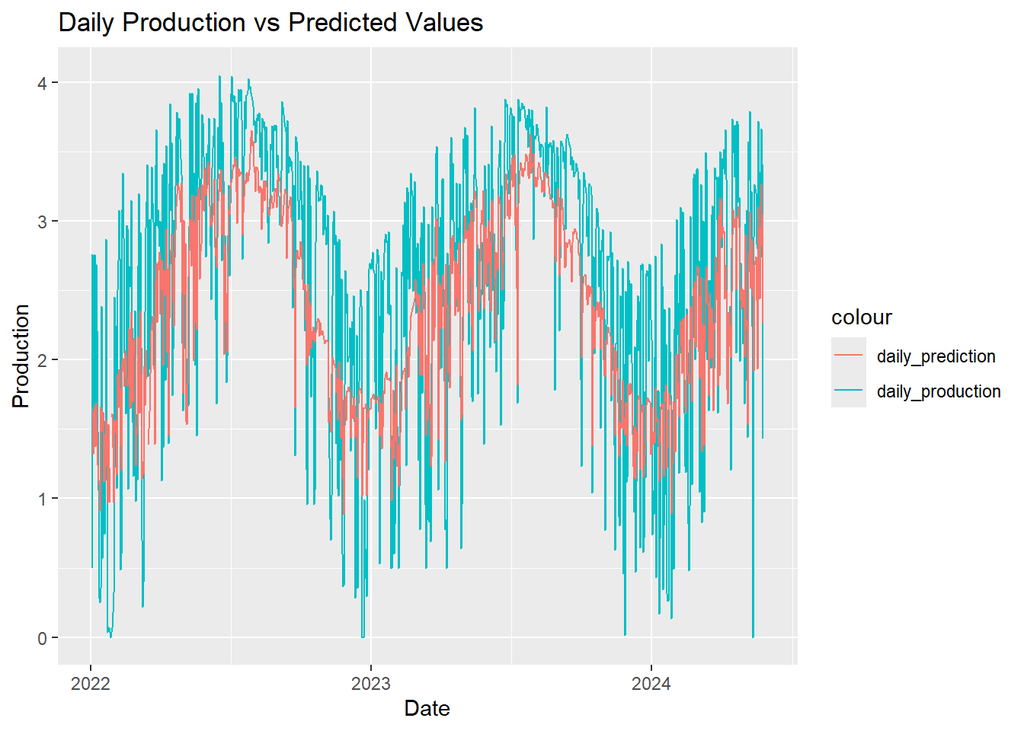

```r
ggplot(daily_pr,aes(x=date)) +geom_line(aes(y = daily_production, color = "daily_production")) + geom_line(aes(y = daily_prediction, color = "daily_prediction")) +ggtitle("Daily Production vs Predicted Values")+xlab("Date")+ylab("Production")
```

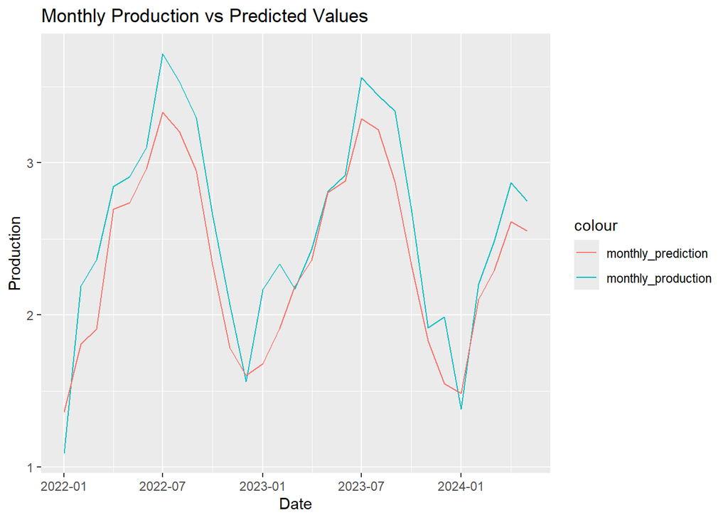

```r
ggplot(monthly_pr,aes(x=date)) +geom_line(aes(y =monthly_production , color = "monthly_production")) + geom_line(aes(y = monthly_prediction, color = "monthly_prediction")) +ggtitle("Monthly Production vs Predicted Values")+xlab("Date")+ylab("Production")
```

The code calculates and visualizes the predicted production values at hourly, daily, and monthly levels using a linear regression model (fit4). First, it computes the squared predictions from the model and adds them to the avgdata_lagged data frame. It then aggregates the data to calculate the daily and monthly mean production and prediction values. For daily predictions, the code groups by date and computes the average production and predicted values. For monthly predictions, it groups by year and month, computing the average production and predictions and formatting the date to represent the first day of each month. The resulting predictions are plotted against actual production values using ggplot2. Three plots are generated: one showing hourly production versus predicted values, one for daily production versus daily predictions, and another for monthly production versus monthly predictions. These visualizations help in assessing the model’s performance across different time scales and provide a clear comparison of actual versus predicted production values. # Hourly Linear Regression Model

```r
# Identify the number of days to forecast
todays_date = as.Date("2024-05-24")
forecast_date = todays_date + 1
latest_available_prod_date = as.Date(max(production_data$date))
n_days = as.numeric(forecast_date - latest_available_prod_date)

# Prepare forecasted production data
forecasted_production = tail(avgdata_lagged, n_days * 24)
forecasted_production[, date := date + n_days]
forecasted_production[, production := NA]

# Combine actual production data with forecasted dates
production_with_forecast = rbind(avgdata_lagged,forecasted_production)



# Reshape data for hourly analysis
mdata = melt(production_with_forecast, id = c("date", "production"))



# Create a data table for hourly production
production_in_hours = data.table()
info_for_hour1 = production_with_forecast[hour == 1]
production_in_hours[, date := info_for_hour1$date]

hours <- c(0, 1, 2, 3, 4, 5, 6, 7, 8, 9, 10, 11, 12, 13, 14, 15, 16, 17, 18, 19, 20, 21, 22, 23)

for (i in hours) {
  colname = paste("V", i, sep = "")
  b = production_with_forecast[hour == i]

  # Ensure the lengths match
  production_in_hours[, (colname) := b$production[rep(1:.N, length.out = .N)]]
}
 print("hey")
```

```
## [1] "hey"
```

```r
 print(production_in_hours)
```

```
##            date    V0    V1    V2    V3    V4    V5    V6    V7    V8    V9
##          <Date> <num> <num> <num> <num> <num> <num> <num> <num> <num> <num>
##   1: 2022-01-02     0     0     0     0  0.00  0.00  0.00  0.00  0.00  0.85
##   2: 2022-01-03     0     0     0     0  0.00  0.00  0.00  0.85  5.10  9.35
##   3: 2022-01-04     0     0     0     0  0.00  0.00  0.00  0.00  0.85  4.25
##   4: 2022-01-05     0     0     0     0  0.00  0.00  0.00  0.00  4.25  8.50
##   5: 2022-01-06     0     0     0     0  0.00  0.00  0.00  0.85  5.10  9.35
##  ---
## 873: 2024-05-23     0     0     0     0  0.07  1.00  2.62  5.90  8.50  9.77
## 874: 2024-05-24     0     0     0     0  0.00  0.02  0.02  2.49  2.43  4.89
## 875: 2024-05-25    NA    NA    NA    NA    NA    NA    NA    NA    NA    NA
## 876: 2024-05-26    NA    NA    NA    NA    NA    NA    NA    NA    NA    NA
## 877: 2024-05-27    NA    NA    NA    NA    NA    NA    NA    NA    NA    NA
##        V10   V11   V12   V13   V14   V15   V16   V17   V18   V19   V20   V21
##      <num> <num> <num> <num> <num> <num> <num> <num> <num> <num> <num> <num>
```

[output cut: 24 more lines]

```r
# Prepare weather data
weatherup = data.table()
weatherup[, date := production_with_forecast$date]
weatherup[, hour := production_with_forecast$hour] # Replace hour with your actual column name
weatherup[, DSWRF_Surface_Avg := production_with_forecast$DSWRF_Surface_Avg] # Replace x1 with your actual column name
weatherup[, TCDC_middle.cloud.layer_Avg := production_with_forecast$TCDC_middle.cloud.layer_Avg] # Replace x2 with your actual column name
weatherup[, CSNOW_surface_Avg := production_with_forecast$CSNOW_surface_Avg] # Replace x3 with your actual column name
weatherup[, TMP_surface_Avg := production_with_forecast$TMP_surface_Avg] # Replace x4 with your actual column name
print(production_with_forecast)
```

```
## Index: <hour>
##              date  hour            dateTime DSWRF_Surface_Avg
##            <Date> <num>              <POSc>             <num>
##     1: 2022-01-02     0 2022-01-02 00:00:00            0.0000
##     2: 2022-01-02     1 2022-01-02 01:00:00            0.0000
##     3: 2022-01-02     2 2022-01-02 02:00:00            0.0000
##     4: 2022-01-02     3 2022-01-02 03:00:00            0.0000
##     5: 2022-01-02     4 2022-01-02 04:00:00            0.0000
##    ---
## 21044: 2024-05-27    19 2024-05-26 19:00:00          380.5424
## 21045: 2024-05-27    20 2024-05-26 20:00:00          310.0134
## 21046: 2024-05-27    21 2024-05-26 21:00:00          258.3430
## 21047: 2024-05-27    22 2024-05-26 22:00:00            0.0000
## 21048: 2024-05-27    23 2024-05-26 23:00:00            0.0000
##        TCDC_low.cloud.layer_Avg TCDC_middle.cloud.layer_Avg
```

[output cut: 64 more lines]

```r
# Calculate daily weather averages
daily_weather = weatherup[, list(TMP_surface_Avg = mean(TMP_surface_Avg), TCDC_middle.cloud.layer_Avg = mean(TCDC_middle.cloud.layer_Avg), DSWRF_Surface_Avg = mean(DSWRF_Surface_Avg), CSNOW_surface_Avg = mean(CSNOW_surface_Avg)), by = list(date)]

print(daily_weather)
```

```
##            date TMP_surface_Avg TCDC_middle.cloud.layer_Avg DSWRF_Surface_Avg
##          <Date>           <num>                       <num>             <num>
##   1: 2022-01-02        272.8917                    66.83150          39.20697
##   2: 2022-01-03        270.3012                    10.90883         123.03210
##   3: 2022-01-04        272.0884                    67.46467          86.20140
##   4: 2022-01-05        272.7680                    10.86200         118.82653
##   5: 2022-01-06        274.3716                     0.00000         104.70073
##  ---
## 873: 2024-05-23        293.8271                    45.02183         321.48955
## 874: 2024-05-24        287.5858                    54.93433         209.65861
## 875: 2024-05-25        285.4890                    68.97783         117.77676
## 876: 2024-05-26        289.3342                    27.60383         324.40145
## 877: 2024-05-27        289.3342                    27.60383         324.40145
##      CSNOW_surface_Avg
##                  <num>
##   1:        0.55166667
##   2:        0.01333333
##   3:        0.00000000
##   4:        0.00000000
##   5:        0.00000000
##  ---
## 873:        0.00000000
## 874:        0.00000000
## 875:        0.00000000
## 876:        0.00000000
## 877:        0.00000000
```

```r
# Merge production and weather data
prod_weather = merge(production_in_hours, daily_weather, by = "date")

print(prod_weather)
```

```
## Key: <date>
##            date    V0    V1    V2    V3    V4    V5    V6    V7    V8    V9
##          <Date> <num> <num> <num> <num> <num> <num> <num> <num> <num> <num>
##   1: 2022-01-02     0     0     0     0  0.00  0.00  0.00  0.00  0.00  0.85
##   2: 2022-01-03     0     0     0     0  0.00  0.00  0.00  0.85  5.10  9.35
##   3: 2022-01-04     0     0     0     0  0.00  0.00  0.00  0.00  0.85  4.25
##   4: 2022-01-05     0     0     0     0  0.00  0.00  0.00  0.00  4.25  8.50
##   5: 2022-01-06     0     0     0     0  0.00  0.00  0.00  0.85  5.10  9.35
##  ---
## 873: 2024-05-23     0     0     0     0  0.07  1.00  2.62  5.90  8.50  9.77
## 874: 2024-05-24     0     0     0     0  0.00  0.02  0.02  2.49  2.43  4.89
## 875: 2024-05-25    NA    NA    NA    NA    NA    NA    NA    NA    NA    NA
## 876: 2024-05-26    NA    NA    NA    NA    NA    NA    NA    NA    NA    NA
## 877: 2024-05-27    NA    NA    NA    NA    NA    NA    NA    NA    NA    NA
##        V10   V11   V12   V13   V14   V15   V16   V17   V18   V19   V20   V21
```

[output cut: 38 more lines]

```r
# Prepare data for a specific hour (e.g., Hour 8)
hour8_prod = data.table()
hour8_prod[, date := prod_weather$date]
hour8_prod[, production := prod_weather$V8]
hour8_prod[, monthFactor := as.factor(format(hour8_prod$date, "%m"))]
hour8_prod[, trend := 1: .N]

# Build and summarize a linear model with a trend component
Model_trend = lm(production ~ trend + monthFactor, hour8_prod)
summary(Model_trend)
```

```
##
## Call:
## lm(formula = production ~ trend + monthFactor, data = hour8_prod)
##
## Residuals:
##    Min     1Q Median     3Q    Max
## -7.282 -1.704  0.379  1.631  6.032
##
## Coefficients:
##                Estimate Std. Error t value Pr(>|t|)
## (Intercept)   1.8528415  0.2635043   7.032 4.16e-12 ***
## trend         0.0018432  0.0003085   5.975 3.37e-09 ***
## monthFactor02 1.4922576  0.3397456   4.392 1.26e-05 ***
## monthFactor03 2.5152301  0.3323781   7.567 9.79e-14 ***
## monthFactor04 3.0483853  0.3357242   9.080  < 2e-16 ***
## monthFactor05 3.8398619  0.3396180  11.306  < 2e-16 ***
## monthFactor06 4.2837259  0.3747620  11.431  < 2e-16 ***
## monthFactor07 5.2237020  0.3709253  14.083  < 2e-16 ***
## monthFactor08 4.3089822  0.3710038  11.614  < 2e-16 ***
## monthFactor09 4.5288185  0.3749925  12.077  < 2e-16 ***
## monthFactor10 4.1154182  0.3718771  11.067  < 2e-16 ***
## monthFactor11 1.9390501  0.3763274   5.153 3.19e-07 ***
## monthFactor12 0.5310477  0.3736972   1.421    0.156
## ---
## Signif. codes:  0 '***' 0.001 '**' 0.01 '*' 0.05 '.' 0.1 ' ' 1
##
## Residual standard error: 2.257 on 861 degrees of freedom
##   (3 observations deleted due to missingness)
## Multiple R-squared:  0.3535, Adjusted R-squared:  0.3445
## F-statistic: 39.23 on 12 and 861 DF,  p-value: < 2.2e-16
```

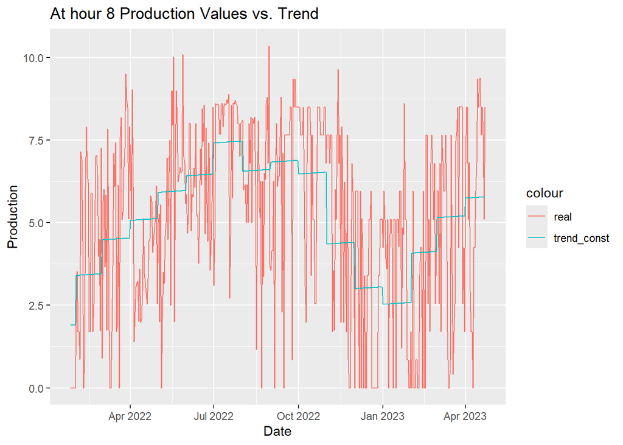

```r
# Predict and plot trend-corrected production values
hour8_prod[, trend_const := predict(Model_trend, hour8_prod)]
ggplot(hour8_prod[25:476], aes(x = date)) + # Replace 25:476 with your actual range
  geom_line(aes(y = production, color = "real")) +
  geom_line(aes(y = trend_const, color = "trend_const")) +
  ggtitle("At hour 8 Production Values vs. Trend") + xlab("Date") + ylab("Production")
```

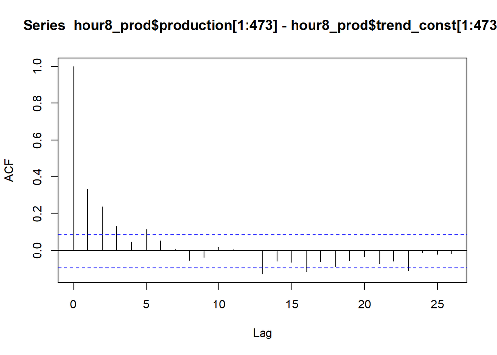

```r
acf(hour8_prod$production[1:473] - hour8_prod$trend_const[1:473]) # Replace 1:473 with your actual range
```

```r
# Add lag and moving average features
hour8_prod[, lag3 := shift(hour8_prod$production, 8L, NA)]
hour8_prod[, ma_2 := ma(hour8_prod$production, order = 2)]
hour8_prod$ma_2[483:486] = hour8_prod$ma_2[482] # Replace 483:486 with your actual range


# Build and summarize a more complex model
Model_trend2 = lm(production ~ trend + monthFactor + lag3 + ma_2, hour8_prod)
summary(Model_trend2)
```

```
##
## Call:
## lm(formula = production ~ trend + monthFactor + lag3 + ma_2,
##     data = hour8_prod)
##
## Residuals:
##     Min      1Q  Median      3Q     Max
## -4.3686 -0.4965 -0.0426  0.6251  7.1148
##
## Coefficients:
##                 Estimate Std. Error t value Pr(>|t|)
## (Intercept)   -0.2595565  0.1550160  -1.674  0.09442 .
## trend         -0.0002416  0.0001714  -1.410  0.15904
## monthFactor02 -0.1956256  0.1834546  -1.066  0.28657
## monthFactor03 -0.3806878  0.1896122  -2.008  0.04499 *
## monthFactor04 -0.3294475  0.1990248  -1.655  0.09823 .
## monthFactor05 -0.3478272  0.2096543  -1.659  0.09747 .
## monthFactor06 -0.5671452  0.2335588  -2.428  0.01538 *
## monthFactor07 -0.7623042  0.2485369  -3.067  0.00223 **
## monthFactor08 -0.5758256  0.2338893  -2.462  0.01402 *
## monthFactor09 -0.6209355  0.2373823  -2.616  0.00906 **
## monthFactor10 -0.5665317  0.2308975  -2.454  0.01434 *
## monthFactor11 -0.2710918  0.2087748  -1.298  0.19447
## monthFactor12 -0.0703103  0.1967197  -0.357  0.72087
## lag3          -0.0089147  0.0177423  -0.502  0.61548
## ma_2           1.1468634  0.0238173  48.153  < 2e-16 ***
## ---
## Signif. codes:  0 '***' 0.001 '**' 0.01 '*' 0.05 '.' 0.1 ' ' 1
##
## Residual standard error: 1.167 on 850 degrees of freedom
##   (12 observations deleted due to missingness)
## Multiple R-squared:  0.8275, Adjusted R-squared:  0.8247
## F-statistic: 291.3 on 14 and 850 DF,  p-value: < 2.2e-16
```

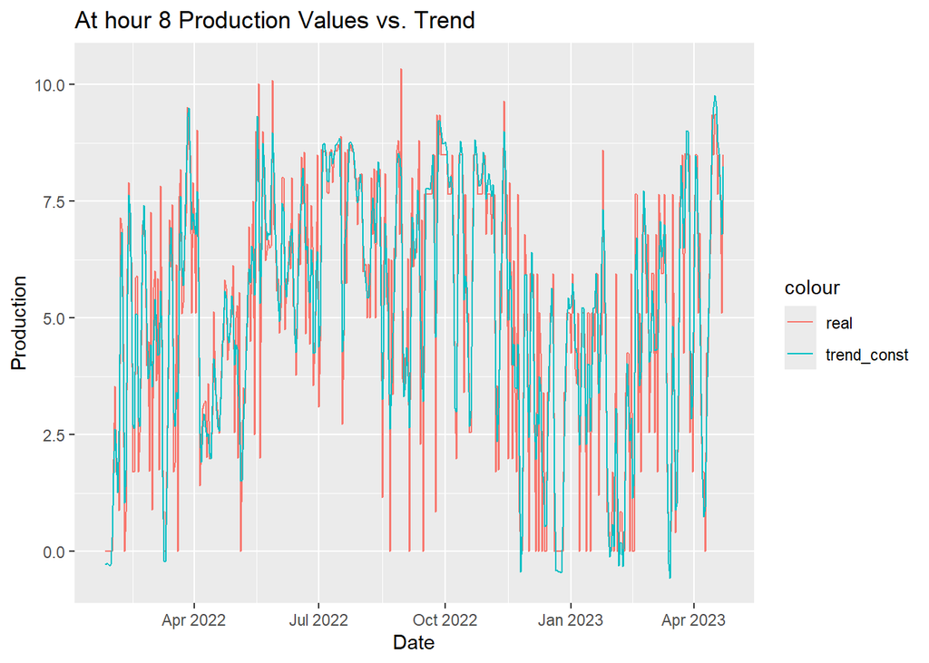

```r
hour8_prod[, lm2 := predict(Model_trend2, hour8_prod)]
ggplot(hour8_prod[25:476], aes(x = date)) + # Replace 25:476 with your actual range
  geom_line(aes(y = production, color = "real")) +
  geom_line(aes(y = lm2, color = "trend_const")) +
  ggtitle("At hour 8 Production Values vs. Trend") + xlab("Date") + ylab("Production")
```

```r
# Correlation analysis of production and weather data
correlation_info = cor(prod_weather[, c(2:29)], method = "pearson", use = "pairwise.complete.obs") # Adjust column range as needed
```

[figure not shown]

```r
ggcorrplot(correlation_info, type = "lower", lab = TRUE)
```

```r
#Include weather variables in the model
hour8_prod[, TCDC_middle.cloud.layer_Avg := prod_weather$TCDC_middle.cloud.layer_Avg]
hour8_prod[, TMP_surface_Avg := prod_weather$TMP_surface_Avg]
hour8_prod[, CSNOW_surface_Avg := prod_weather$CSNOW_surface_Avg]
hour8_prod[, DSWRF_Surface_Avg := prod_weather$DSWRF_Surface_Avg]
```

The provided R code forecasts and analyzes hourly production values by integrating weather data. It begins by identifying the number of days to forecast based on the latest available production date and prepares forecasted production data by extending the dates and setting future production values to NA. It combines historical production data with the forecasted dates, reshapes the data for hourly analysis, and creates a data table to store hourly production values. The code then prepares weather data, calculates daily weather averages, and merges this with the production data. For a specific hour (e.g., hour 8), it creates a new data table and adds columns for trend and month factors. Linear regression models are built and summarized to analyze production trends and the influence of weather variables, with predictions plotted against actual values to assess model performance. This process is crucial for making informed decisions based on forecasted production and understanding the impact of weather on production values.

```r
model_with_regressors = lm(production ~ trend + monthFactor + DSWRF_Surface_Avg + TMP_surface_Avg + ma_2 + lag3 , hour8_prod)
summary(model_with_regressors)
```

```
##
## Call:
## lm(formula = production ~ trend + monthFactor + DSWRF_Surface_Avg +
##     TMP_surface_Avg + ma_2 + lag3, data = hour8_prod)
##
## Residuals:
##     Min      1Q  Median      3Q     Max
## -4.2312 -0.5403 -0.0669  0.6220  6.1607
##
## Coefficients:
##                     Estimate Std. Error t value Pr(>|t|)
## (Intercept)        2.283e+00  2.968e+00   0.769 0.442087
## trend              9.115e-05  1.774e-04   0.514 0.607465
## monthFactor02     -4.410e-01  1.811e-01  -2.435 0.015095 *
## monthFactor03     -7.880e-01  1.954e-01  -4.032 6.03e-05 ***
## monthFactor04     -1.054e+00  2.560e-01  -4.119 4.18e-05 ***
## monthFactor05     -1.117e+00  2.743e-01  -4.072 5.09e-05 ***
## monthFactor06     -1.361e+00  3.247e-01  -4.191 3.07e-05 ***
## monthFactor07     -1.768e+00  3.651e-01  -4.842 1.53e-06 ***
## monthFactor08     -1.374e+00  3.756e-01  -3.658 0.000270 ***
## monthFactor09     -1.088e+00  3.161e-01  -3.443 0.000605 ***
## monthFactor10     -5.631e-01  2.595e-01  -2.170 0.030295 *
## monthFactor11     -8.579e-02  2.167e-01  -0.396 0.692317
## monthFactor12      1.012e-01  1.956e-01   0.518 0.604814
## DSWRF_Surface_Avg  7.340e-03  1.000e-03   7.339 5.04e-13 ***
## TMP_surface_Avg   -1.195e-02  1.105e-02  -1.082 0.279694
## ma_2               1.057e+00  2.699e-02  39.153  < 2e-16 ***
## lag3              -7.384e-03  1.737e-02  -0.425 0.670869
## ---
## Signif. codes:  0 '***' 0.001 '**' 0.01 '*' 0.05 '.' 0.1 ' ' 1
##
## Residual standard error: 1.131 on 847 degrees of freedom
##   (13 observations deleted due to missingness)
## Multiple R-squared:  0.8382, Adjusted R-squared:  0.8352
## F-statistic: 274.3 on 16 and 847 DF,  p-value: < 2.2e-16
```